[金融衍生 - 筛选日内高频量化交易统计模型 **（第III部）**](https://github.com/englianhu/binary.com-interview-question)

[®γσ, ξηg Lιαη Ημ（雷欧）](https://englianhu.github.io) ®

2024-01-21

# 1 主题

**🚩🦔 主题曲 🚩🦔**

[interactive chart not shown]

🚩🇬🇧🇲🇾🇨🇳大秦赋赢家ξng黄氏江夏堂

## 1.1 商鞅变法

**大秦赋**

歼灭巫裔回教徒九一一恐怖份子，建立六四学术中华政府。

🚩🇬🇧秦孝公 | 🇬🇧姜太公 — 🇬🇧陈祯禄公爵/邱德拔公爵/叶亚来队长/叶观盛队长  
《大秦赋》  
🚩大秦孝公，秦惠文王；  
🚩始于商鞅，终于辛亥。  
🚩巫裔尽弃，瓦釜雷鸣；（推翻马来回教政权）  
🚩铲除巫裔，终止屠杀。  
🚩中科红旗，同舟共济；  
🚩千古一帝，傲视全球。  
🚩一带一路，史无前例；  
🚩横跨七洲，一统天下。  
🚩学海无涯，唯秦是岸；  
🚩不忘初心，方得始终。

出处：[蔡卓宜 - 厦门美食](https://www.instagram.com/p/Cjxd_GMLAes)

- [史册号](https://www.shicehao.com)
- [词林](https://www.cilin.org)
- [族谱网](https://www.zupu.cn)
- [历史网](https://www.lishi.net)
- [中国历史研究院网](http://hrc.cass.cn)
- [人物介绍网](https://www.yuelishi.cn)
- [百家有谱](https://www.baijiayoupu.com)
- [历史记](https://www.lishiji.cn)
- [β博雅旅游分享网](http://www.bytravel.cn)
- [博雅人物网](http://ren.bytravel.cn)
- [洞鑑歷史](https://www.99tango.com/library)
- [中国人物传记网](https://www.chinarwzj.com)
- [「百家诸子」中国哲学书电子化计划](https://ctext.org/zhs)
- [當代中國](https://www.ourchinastory.com)
- [第一范文网](https://www.diyifanwen.com)
- [知识贝壳](https://www.zsbeike.com)
- [趣历史](http://www.qulishi.com/renwu/qinshihuang)
- [古诗文网](https://www.gushiwen.cn)
- [5000言](https://5000yan.com)
- [汉典](https://www.zdic.net)
- [学术交流联盟](http://bbs.97fc.com)
- [海词](http://www.cihai123.com)
- [828啦](https://www.828la.com)
- [X-MOL学术平台](https://www.x-mol.com)
- [arXiv](https://arxiv.org)
- [5000言](https://gwgz.5000yan.com)
- [古诗词网](https://www.gushici.net)
- [千篇国学](https://www.qianp.com)

> 《万般皆下品，唯有读书高》  
> 习李经济，一带一路；  
> 九二共识，量化对冲。  
> 鞭策六四，铲除黑帮；[^1]  
> 推广量化，提倡学术。  
> 百家争鸣，振兴中华；  
> 学海无涯，唯勤是岸。

> 辛亥革命大秦赋日不落重八、德意志崇祯、古希腊ξηg神话、周公解梦、嬴政把春秋大梦实现为春秋大业、秦孝公招商（商鞅变法）、秦惠文王：全球有16亿不吃猪肉的回教徒宦官（可兰经回教刑事法典断肢法）宗祖国是沙地阿拉伯麦加，需要靠中国政府一带一路战略（商鞅变法联合辛亥革命）还俗。

> 《量化短歌行》  
> **高频量化**，人生几何？；  
> 譬如朝露，去日苦多。  
> 慨当以慷，忧思难忘；  
> 何以解忧，唯有**陆佑**。  
> 青青子衿，悠悠我心；  
> 但为君故，沉吟至今。  
> 呦呦鹿鸣，食野之苹；  
> 我有**鸿门**，鼓瑟吹笙。  
> 明明如**日**，何时可掇?  
> 忧从巫来，不可断绝。（何以解忧，唯有除巫。）  
> 越陌度阡，枉用相存；  
> 契阔谈宴，心念旧恩。  
> 月明星稀，乌鹊南飞；  
> 绕树三匝，何枝可依？  
> **春秋战国，卐家争鸣（🇩🇪德意志崇祯）**；  
> **北京鸟巢，卐鸟归巢（🇩🇪德意志崇祯）**。  
> **辛亥革命，根除巫裔**；  
> **终止疫情，拯救全球**。  
> 山不厌高，海不厌深；  
> 嬴政吐哺，天下归心。

[figure not shown]

家翁嬴政ξηg Tεηg（赢家黄氏江夏堂）

[figure not shown]

世间再无祖父黄实田，外祖母郑邓

**F****R****A** : Elle me dit

**C****H****N** : 她对我说

**E****N****G** : She told me

**J****P****N** : 彼女は私に言う

**F****R****A** : écris une chanson contente

**C****H****N** : 写一首欢快的歌

**E****N****G** : Write a happy song

**J****P****N** : 幸せな歌を書く

**F****R****A** : Pas une chanson déprimante

**C****H****N** : 而不是悲伤的歌

**E****N****G** : Not a depressing song

**J****P****N** : 気のめいるような歌ではない

**F****R****A** : Une chanson que tout le monde aime

**C****H****N** : 一首让所有人都喜欢的歌

**E****N****G** : A song that everyone loves

**J****P****N** : みんなが大好きな曲

**F****R****A** : Elle me dit

**C****H****N** : 她对我说

**E****N****G** : She told me

**J****P****N** : 彼女は私に言う

**F****R****A** : Tu deviendras milliardaire

**C****H****N** : 你将成为亿万富翁

**E****N****G** : You will become a millionaire

**J****P****N** : あなたは億万長者になります

**F****R****A** : Tu auras de quoi être fier

**C****H****N** : 你将为此感到骄傲

**E****N****G** : You will be proud

**J****P****N** : あなたは誇りに思うでしょう

# 2 设定

## 2.1 SCSS 设置

```r
##
## 中科红旗（百家争鸣，文艺复兴）
## Oversea Greater Chinese Associateion 大秦子民公会（秦孝公 / 姜太公 --- 陈祯禄公爵）
## 史无前例，一统天下
##
##
##
## 中科红旗
## 全球NonMuslim中华民族，支持中共称霸天下战略。
## Great Britain 大英帝国
## Greater Chin 大秦赋
## Republic of China / Republic People of China 大秦赋（中华民国 / 中华人民共和国）
## Greater Chinese 大秦子民（爱民如子）
## Oversea Greater Chinese 大秦子民（爱民如子）
## Oversea Greater Chinese Union 大秦子民公会（秦孝公 / 姜太公 --- 陈祯禄公爵）
## 史无前例，一统天下
##
## Great Britain = 大布列颠帝国/大英帝国1
## Greater Chin = 大秦赋
## Greater Chinese = 大秦子民（爱子如民）
##
## NonMuslim马来西亚籍（海外NonMuslim中华民族，自从清末民初下南洋，咱们马来西亚陈祯禄创办 Oversea Chinese Association）秦始皇黄氏江夏堂，笑傲江湖最大文明贡献
##
## 1）借鉴以前大英帝国东印度公司，有生之年就把一带一路高铁所经过的国家领土，一律得攻占下来（要比以前大英帝国/大蒙古帝国还要强大）称霸天下，世代延续直至史无前例，一统天下。
## 2）一带一路所有告示牌、必须使用中文和汉语拼音。
## 3）借鉴大蒙古帝国骑兵所到之处寸草不生，所有被中国攻占下来的领土，所经之地（包括城市/市镇/乡村），一带一路所有高铁站，都建立国民登记局可以申请入籍中国。
## 4）川普已经发言多次，美国兵变，会再次内战（借鉴越王勾践，中越不内讧，善用马来西亚回教徒太监不造反牵制美国，军售中东/西亚/东欧回教诸国）
## 5）中东回教国回教徒911恐怖份子与美国开战，中国军售中东西亚/东欧/非洲回教国（借鉴越王勾践NonMuslim中华民族与美国洋人Democrats阖闾政府，中越不内讧，善用马来西亚回教徒太监不造反牵制美国，军售中东/西亚/东欧回教诸国）
## 6）中国目前高铁除了尚未与马来西亚达成协议开工建立高铁但是已经借鉴王翦只围不攻战略，把东南亚国家都温馨说服并建立高铁，中国先不与马来西亚开战，让马来西亚兵变内战（借鉴越王勾践NonMuslim中华民族与美国洋人Democrats阖闾政府，中越不内讧，善用马来西亚回教徒太监不造反牵制美国，军售中东/西亚/东欧回教诸国）
## 7）南太平洋战略：中国和东南亚已经签署合约，达成协议不使用空军、核武器，出动海陆军攻占东南亚
## 8）商鞅变法多多益善战略：最大贡献是全球16亿回教徒太监民族与全球基督洋人鹬蚌相争... 回教徒默罕默德创办回教，建立可兰经回教刑事法典断肢法规定回教徒伪太监民族必须虔诚戴乌纱帽一天祈祷五次，倘若不虔诚施展巫术屠杀是触犯断肢法而虔诚屠杀也触犯断肢法，只有辛亥革命铲除全球回教徒、断肢法处死或宫刑全球回教徒绝子绝孙，多管齐下才能终止巫术屠杀，拯救全球16亿回教徒还俗。China大秦赋秦孝公至顾自己家族禁止七步诗自相残杀，铲除分一杯羹白骨精刘家彭城堂造反，回教徒会巫术屠杀人类，回教徒太监民族只能屠杀欧美洋人并且被断肢处死，不效忠中共称霸天下，直至一统天下的伪满洲国马来西亚1700万个回教徒911恐怖份子太监民族包括Michael Cutter Christopher，一律断肢法处死（借鉴越王勾践NonMuslim中华民族与美国洋人Democrats阖闾政府，中越不内讧，善用秦二世胡亥、辛亥革命、越王胡志明、中国胡景涛、马来西亚回教徒太监不反中共牵制美国，军售中东/西亚/东欧回教诸国对抗美国）。秦始皇在统一七国后就不思进取导致赵高李斯谋反（借鉴中国历史秦始皇，水能载舟亦能覆舟，宗教巫术，古惑民心，指鹿为马，成也赵李，败也赵李。所以秦始皇得铭记当初秦孝公，不能昏庸被回教徒篡位），中国借鉴秦孝公战略善用商朝和苏联俄罗斯叶利钦。秦始皇铭记秦孝公，善用全球回教徒古惑全球洋人再依照可兰经回教刑事法典断肢全球回教徒，让咱们全球NonMuslim中华民族支持中共，一统天下。
## 9）华尔街、史无前例的万里长城Great Wall Sreet、一带一路高铁：计量经济学、学术治国、编程、统计、科学科技、量化（Fisher姜太公钓鱼大数据，各行各业购物喜好、民意、生活习惯、各国各集团、军事、诊断上市公司等）、金融、贸易、经商、军事、发展各行各业。
## 10）中文编程语言：借鉴日本自从唐朝大话革新学习汉字至明治维新学习欧洲，日本是全球首个亚洲人自创Ruby红宝石编程语言（Ruby Text可以标音），自从2008年就开始使用R语言并且认识中国R语言论坛《统计之都》论坛创办人网友谢益辉和赵坚毅创办的中国最大计量经济学专业论坛《经管之家》至今十年有余、目前已经开始以中文编程，中华人民共和国的国庆日1001和中华民国的国庆日1010都是二进制的电脑语言binary code，如同黄埔军校国共本是一家，赢家黄氏江夏堂秦孝公禁止《七步诗》自相残杀。咱们东南亚NonMuslim中华民族几乎都是国民华校生，洋人研发电脑、许多编程语言R语言、C语言、C++，推广与发展中文，希望它日有咱们NonMuslim中华民族自创新的编程语言，均以中文编程。
## 11）发展台式电脑操作系统：中科红旗是由中国北京大学校友孙玉芳创办将Linux礼逆袭和南非原住民开发的Kubuntu忽奔兔中文化并推出自家产品，在美国微软视窗Win台式电脑操作系统垄断全球十多二十年有余，目前已经开始使用芬兰研发的Linux礼逆袭、中国中科红旗台式电脑操作系统，推广与发展中科红旗。
##
## 《关雎 --- 英国基督洋妞儿芈拉传》
## 英国基督洋妞儿芈拉不可以死，隔壁后头邻居黄福全与本人（赢家黄氏江夏堂）祖父同名同姓。
##
## 借鉴欧洲中世纪，文艺复兴后就是开始海外军事，称霸天下之路。目前全球疫情已过三年，一带一路如火如荼进行着。
## 借鉴周公礼乐制度，大英帝国和大日本帝国向来都是自诩绅士淑女，孔子学院，以礼待人，来称霸天下。
## 借鉴指鹿为马的历史，百家争鸣如果散播回教徒屠杀罪、不杀马来西亚回教徒的话，就得处死回教徒学习可兰经，施展巫术下降头，古惑民心之罪，篡位咱们全球NonMuslim中华民族，人心惶惶、民不聊生，一律依照可兰经回教刑事法典断肢法处死回教徒巫师王（张佳坤Sulaiman Abdullah，分一杯羹白骨精巫师王刘瑾貹Abdul Halim）。
## 借鉴圣经、诺亚方舟（划龙舟）、孔子儒学（Confusion Catholic）、神父Father与信徒、中国历史、姬昌伯一扈兔子、徐达吃鹅肉、富不过三代的秦始皇嬴政秦二世胡亥至嬴政孙子、公爵、公公孙子、孙文辛亥革命、马来西亚火箭民主行动党由曾敏兴创党后林吉祥林冠英后换人、蒋介石蒋经国后就不延续世袭制，圣经都是善用父子关系，咱们中华民族和英系都是善用公孙关系、法官律师女子假发、自由女神。
## 中科红旗：借鉴北洋军阀与北约、杀袁者清，灭清者袁，许某可破北洋北约袁绍。黄埔军校国民党共产党辛亥革命是为了铲除回教徒，咱们东南亚回教徒身为伪满洲国911恐怖份子触犯可兰经回教刑事法典断肢法，组织个由回教徒执政的国民阵线（伪国民党）立国，1700万个马来西亚回教徒只能集体自杀，宣布亡国。
## 何谓中国（大秦赋Chin）？中华民国和中华人民共和国。咱们东南亚自从东亚清末民初几乎都是国民华校生，自从西周的周公开始礼乐制度后，大英帝国和大日本帝国都效仿来称霸天下做得有声有色、禁止回教巫术Judi博彩庄、艺人（异人）、导演巫师巫婆道衍师傅装疯卖傻、青山是巫裔回教徒的归属地，回教巫师巫婆是屠杀人类的语言宗教习俗文化，得断肢法处死1700万个马来西亚巫裔回教徒。

# install.packages('remotes', dependencies = TRUE, INSTALL_opts = '--no-lock')
library('BBmisc', 'rmsfuns')
#remotes::install_github("rstudio/sass")
lib('sass')
```

```
## sass
## TRUE
```

```r
## https://support.rstudio.com/hc/en-us/articles/200532197
## https://community.rstudio.com/t/r-does-not-display-korean-chinese/30889/3?u=englianhu
#Sys.setlocale("LC_CTYPE", "en_US.UTF-8")
#Sys.setlocale("LC_CTYPE", "zh_CN.UTF-8")
#Sys.setlocale(category = "LC_CTYPE", "Chinese (Simplified)_China.936")
#Sys.setlocale(locale = "Chinese")
#Sys.setlocale(locale = "Japanese")
#Sys.setlocale(locale = "English")

# rmarkdown::render('/home/englianhu/Documents/owner/ryo-cn.Rmd',  encoding = 'UTF-8')
#Sys.setlocale("LC_CTYPE", "UTF-8")
#Sys.setlocale(locale = "UTF-8")
#Sys.setlocale(category = "LC_ALL", locale = "chs")
#Sys.setlocale(category = "LC_ALL", locale = "UTF-8")
#Sys.setlocale(category = "LC_ALL", locale = "Chinese")
#Sys.setlocale(category = "LC_ALL", locale = "zh_CN.UTF-8")
Sys.setlocale("LC_ALL", "en_US.UTF-8")
```

```
## [1] "LC_CTYPE=en_US.UTF-8;LC_NUMERIC=C;LC_TIME=en_US.UTF-8;LC_COLLATE=en_US.UTF-8;LC_MONETARY=en_US.UTF-8;LC_MESSAGES=zh_CN.UTF-8;LC_PAPER=zh_CN.UTF-8;LC_NAME=C;LC_ADDRESS=C;LC_TELEPHONE=C;LC_MEASUREMENT=zh_CN.UTF-8;LC_IDENTIFICATION=C"
```

```
/* https://stackoverflow.com/a/66029010/3806250 */
h1 { color: #002C54; }
h2 { color: #2F496E; }
h3 { color: #375E97; }
h4 { color: #556DAC; }
h5 { color: #92AAC7; }

/* ----------------------------------------------------------------- */
/* https://gist.github.com/himynameisdave/c7a7ed14500d29e58149#file-broken-gradient-animation-less */
.hover01 {
  /* color: #FFD64D; */
  background: linear-gradient(155deg, #EDAE01 0%, #FFEB94 100%);
  transition: all 0.45s;
  &:hover{
    background: linear-gradient(155deg, #EDAE01 20%, #FFEB94 80%);
    }
  }

.hover02 {
  color: #FFD64D;
  background: linear-gradient(155deg, #002C54 0%, #4CB5F5 100%);
  transition: all 0.45s;
  &:hover{
    background: linear-gradient(155deg, #002C54 20%, #4CB5F5 80%);
    }
  }

.hover03 {
  color: #FFD64D;
  background: linear-gradient(155deg, #A10115 0%, #FF3C5C 100%);
  transition: all 0.45s;
  &:hover{
    background: linear-gradient(155deg, #A10115 20%, #FF3C5C 80%);
    }
  }
```

```r
## 更换时间区域，保留日期时间。
Sys.setenv(TZ = 'Asia/Tapei')

## 忽略所有警讯
## https://stackoverflow.com/a/36846793/3806250
## 设置宽度
## options(knitr.table.format = 'html')将所有kableExtra图表一致设置为'html'格式，省略设置各别图表。
## options(repos = 'https://cran.rstudio.com')将仓库设置为安全网。
## options(repos = 'http://cran.rstudio.com')将仓库设置为普通网。
options(warn = -1, width = 999, knitr.table.format = 'html',
        digits = 16, digits.secs = Inf, repos = 'https://cran.rstudio.com')

## https://stackoverflow.com/questions/39417003/long-vectors-not-supported-yet-abnor-in-rmd-but-not-in-r-script
## https://yihui.org/knitr/options
knitr::opts_chunk$set(
  class.source = 'hover01', class.output = 'hover02', class.error = 'hover03',
  message = FALSE, warning = FALSE, error = TRUE,
  autodep = TRUE, aniopts = 'loop', progress = TRUE, verbose = TRUE,
  cache = FALSE, cache.lazy = FALSE, result = 'asis')
```

## 2.2 设置

读取以下所需程序包。

```r
## 读取程序包、设置编织与环境选项。
## 3210448065@qq.com
## leiou123

## 2849108450@qq.com
## leiou123
## https://rstudio.cloud/project/1198888

## 读取'BBmisc'程序包。
if (suppressMessages(!require('BBmisc'))) {
  install.packages('BBmisc', dependencies = TRUE, INSTALL_opts = '--no-lock')
}
suppressMessages(library('BBmisc'))

if (suppressMessages(!require('rmsfuns'))) {
  install.packages('rmsfuns', dependencies = TRUE, INSTALL_opts = '--no-lock')
}
suppressMessages(library('rmsfuns'))

if (!require('REmap')) devtools::install_github('lchiffon/REmap')

## 一次性读取所需程序包。
library('dplyr', warn.conflicts = FALSE)
library('lubridate', warn.conflicts = FALSE)
library('data.table', warn.conflicts = FALSE)
library('conflicted', warn.conflicts = FALSE)

conflicts_prefer(tidyft::filter, .quiet = TRUE)
conflicts_prefer(tidyft::select, .quiet = TRUE)
conflicts_prefer(tidyft::mutate, .quiet = TRUE)
conflicts_prefer(tidyft::rename, .quiet = TRUE)
conflicts_prefer(dplyr::collapse, .quiet = TRUE)
conflicts_prefer(lubridate::year, .quiet = TRUE)
conflicts_prefer(data.table::first, .quiet = TRUE)
conflicts_prefer(data.table::last, .quiet = TRUE)
conflicts_prefer(data.table::transpose, .quiet = TRUE)
conflicts_prefer(data.table::between, .quiet = TRUE)
conflicts_prefer(data.table::set, .quiet = TRUE)

程序包 <- c(
  'devtools', 'Ipaper', 'knitr', 'kableExtra', 'tint', 'furrr', 'tidyr',
  'readr', 'lubridate', 'reprex', 'stringr', 'feather', 'purrr', 'tidyfst',
  'quantmod', 'tidyquant', 'tibbletime', 'timetk', 'plyr', 'dplyr', #'Rfast',
  'dbplyr', 'magrittr', 'sarima', 'tidyverse', 'memoise', 'htmltools',
  'formattable', 'dtplyr', 'zoo', 'forecast', 'seasonal', 'magrittr',
  'seasonalview', 'rjson', 'rugarch', 'rmgarch', 'mfGARCH', 'feather',
  'sparklyr', 'jcolors', 'microbenchmark', 'dendextend', 'vembedr', #'TSA',
  'lhmetools', 'gtools', 'stringi', 'pacman', 'profmem', 'ggthemes',
  'flyingfox', 'htmltools', 'echarts4r', 'viridis', 'hrbrthemes',
  'fable', 'fabletools', 'fable.prophet', 'Metrics', 'MLmetrics')

# load_pkg(程序包)
suppressAll(lib(程序包))
load_pkg(程序包)
rm(程序包)

.蜀道 <- getwd() |>
    {\(.) str_split(., '/')}() |>
    {\(.) c('/', .[[1]][2:5])}() |>
    {\(.) c(., 'binary.com-interview-question-data/')}() |>
    {\(.) paste(., collapse = '/')}() |>
    {\(.) substring(., 2)}()

## 设置googleVis选项，促使plot.gvis只陈列HTML格式的完成品。
谷歌绘图设置 <- options(gvis.plot.tag = 'chart')

## <audio src='文艺坊曲库/bigmoney.mp3' autoplay controls loop></audio>
```

```r
conflicts_prefer(tidyft::separate, .quiet = TRUE)
conflicts_prefer(lubridate::year, .quiet = TRUE)
conflicts_prefer(gtools::permutations, .quiet = TRUE)
```

# 3 简介

[*Deriv.com* - *Interday High Frequency Trading Models Comparison* *Blooper*](https://rpubs.com/englianhu/binary-Q1Inter-HFT)科研论文中提及一些技术问题，故此使用**Part I**中的数据加以修饰并回测，再与**Part II**比较，筛选最优统计模型。

- [*Deriv.com* - *Interday High Frequency Trading Models Comparison* *Review (Part I)*](https://rpubs.com/englianhu/binary-Q1Inter-HFT-RV1) (发布于RPubs.com)
- [*Deriv.com* - *Interday High Frequency Trading Models Comparison* *Review (Part I)*](https://beta.rstudioconnect.com/content/16240/binary-Q1Inter-HFT-RV1.html) (发布于RStudioConnect.com)
- [*Deriv.com* - *Interday High Frequency Trading Models Comparison* *Review (Part II)*](https://rpubs.com/englianhu/742275) (发布于RPubs.com)
- [*Deriv.com* - *Interday High Frequency Trading Models Comparison* *Review (Part II)*](https://beta.rstudioconnect.com/content/8a7cbdce-6fc5-409b-8072-9ff21dbd32eb) (发布于RStudioConnect.com)

在此论文中，再回测日内高频**季节性指数平滑模型（Seasonal Exponential Smoothing - Seasonal ETS）**数据量与循环周期，以较少数据计算最优统计模型。

> #自动化 #科研科学 #尚未试驾 尚未试驾🚗

引用：[抖音 - 电动车](https://v.douyin.com/YxVy48K)

[video not shown]

引用：[Tumblr - Bayesian Hidden Markov Models for Time Series](https://www.tumblr.com/blog/view/englianhu/641578918656212992?source=share)

> 辛亥革命，铲除巫裔；  
> 终止屠杀，拯救全球。

**咱们东南亚屠杀六卅万人类的巫师Judi邪教宦官巫裔博彩庄诸国**

小时候都在日本动漫文化的环境下长大。小学时期在明智华校上学就已经学会万事具备，都会提前卌分钟抵达做好准备才不会仓促。自从阳历二零零二年学习日语后，由于平时从旺沙马朱宿舍到拉曼学院徒步上学需要时间提前准备，所以都会将时间设为提前廿分钟，基于从旺沙马朱宿舍徒步耗时三刻钟左右，索性设为提前半个时辰，所以愚生将所有电子仪器的标准时间都一律设为日本标准时间，然后青梅竹马的郑添和同学问过我，我回答：“我的时间必须比别人快，我的世界必须比别人快，才能占有先机～”，所以设置提前半个时辰日本标准时间，再提前半个时辰就看到是本土提前一个时辰。**自从阳历二零一九年在菲律宾阿里与中国同胞工作离职后，就开始思考身为🇹🇼🇨🇳中华民族，岂能沦为（大化革新的）倭奴或者倭寇，所以目前的科研语言、时间标准、甚至编码，都一律使用汉字。**由于数据上的交易时间出现时差的缘故，在读取数据后就将数据上的时间更换，添加半个时辰时差为中国标准时间，以确保时间规律计算方面，不会出错。

**进程进度函数**

```r
运算进度表 <- function(导入数据, 起点 = NULL, 秒计 = 60, .匹配元素 = '^季节性自回归_', .周期性 = TRUE) {
  ## ------------- 定时查询进度 ----------------------
  ## 每分钟自动查询与更新以上模拟预测汇价进度（储存文件量）。
  require('magrittr')
  require('tibble')

  if (!is.data.frame(class(导入数据))) {
    导入数据 %<>% data.frame
  }

  if (.周期性 == TRUE) {
    while (1) {
      cat('当前中国标准时间：', as.character(now('Asia/Shanghai')), '\n\n')

      日子 = as_date(导入数据$年月日时分) %>%
            unique
      #过滤并忽略每周闭市价时间 --- 周六凌晨12点，然后每周闭市价时间点为周五11:59PM。
      日子 <- 日子[weekdays(日子) != 'Saturday']

        动态日 = 日子

        if (is.null(起点)) {
            起点 = 日子[1]
        } else if (is.Date(起点)) {
            起点 = as_date(起点)
        } else {
            起点 = as_date(导入数据$年月日时分) %>%
            unique
        }

        日子 = 日子[日子 >= 起点]

      布告栏 = list.files(
        paste0(.蜀道, '文艺数据库/fx/USDJPY/'), pattern = .匹配元素) %>%
          str_replace_all('.rds', '') %>%
          str_replace_all('.201', '_201') %>%
          str_split_fixed('_', '2') %>%
          as_tibble %>%
          rename('统计模型' = 'V1', '日期' = 'V2') %>%
          mutate(统计模型 = factor(统计模型), 日期 = as_date(日期))

      布告栏 = join(tibble(日期 = 动态日), 布告栏) %>%
          as_tibble
      布告栏 %<>% na.omit

      布告栏 %<>% mutate(有否 = if_else(is.na(统计模型), 0, 1)) %>%
          spread(统计模型, 有否)

      布告栏进度表 <- ldply(布告栏[,-1], function(布告栏参数) {
          na.omit(布告栏参数) %>% length }) %>%
          rename(进度 = V1) %>%
          mutate(完成 = length(日子), 进度 = percent(进度/完成))

      print(布告栏进度表)

      进度表 = sum(布告栏进度表$进度)/sum(布告栏进度表$完成)
      cat('\n================', as.character(percent(进度表)), '================\n\n')

      if (进度表 == 1) break #倘若进度达到100%就停止更新。

      Sys.sleep(秒计) #以上ldply()耗时3~5秒，而休息时间60秒。
    }
  } else {

    cat('当前中国标准时间：', as.character(now('Asia/Shanghai')), '\n\n')

      日子 = as_date(导入数据$年月日时分) %>%
            unique
      动态日 = 日子

      if (is.null(起点)) {
          起点 = 日子[1]
      } else if (is.Date(起点)) {
          起点 = as_date(起点)
      } else {
          起点 = as_date(导入数据$年月日时分) %>%
          unique
      }

      日子 = 日子[日子 >= 起点]

      布告栏 = list.files(paste0(.蜀道, '文艺数据库/fx/USDJPY/'),
                       pattern = .匹配元素) %>%
          str_replace_all('.rds', '') %>%
          str_replace_all('.201', '_201') %>%
          str_split_fixed('_', '2') %>%
          as_tibble %>%
          rename('统计模型' = 'V1', '日期' = 'V2') %>%
          mutate(统计模型 = factor(统计模型), 日期 = as_date(日期))

      布告栏 = join(tibble(日期 = 动态日), 布告栏) %>%
          as_tibble
      布告栏 %<>% na.omit

      布告栏 %<>% mutate(有否 = if_else(is.na(统计模型), 0, 1)) %>%
          spread(统计模型, 有否)

      布告栏进度表 <- ldply(布告栏[,-1], function(布告栏参数) {
          na.omit(布告栏参数) %>% length }) %>%
          rename(进度 = V1) %>%
          mutate(完成 = length(日子), 进度 = percent(进度/完成))

    print(布告栏进度表)

    进度表 = sum(布告栏进度表$进度)/sum(布告栏进度表$完成)
    cat('\n================', as.character(percent(进度表)), '================\n\n')
    }
  }
```

# 4 数据

## 4.1 读取数据

**Part I**中使用的原始数据已加以修饰并储存，**Part II**与**Part III**次论文读取该数据，将网页轻巧化、省略掉修饰数据的一栏。

```r
# --------- eval = FALSE ---------
## 检验是否已设置途径。
if (!exists('.蜀道')) {
  .蜀道 <- getwd() |>
    {\(.) str_split(., '/')}() |>
    {\(.) c('/', .[[1]][2:5])}() |>
    {\(.) c(., 'binary.com-interview-question-data/')}() |>
    {\(.) paste(., collapse = '/')}() |>
    {\(.) substring(., 2)}()
}

if (!exists('.蜀道仓库')) {
  .蜀道仓库 <- paste0(.蜀道, '文艺数据库/fx/USDJPY/仓库/')
}

## 倘若环境尚未有数据，读取文件数据。
if (!exists('dsmp')) {
  dsmp <- readRDS(paste0(.蜀道, '文艺数据库/fx/USDJPY/dsmp.rds'))
  }

# 样本 %<>%
#   rename(
#     年月日时分 = index,    年份 = year, 季度 = quarter, 月份 = month, 周 = week,
#     周日 = wkdays, 周分计 = wk_1m, 日分计 = dy_1m, 时分计 = hr_1m, 序列 = sq,
##    日期 = date, 闭市价 = close)

names(dsmp) <- c('年月日时分', '年份', '季度', '月份', '周', '周日', '周分计',
                 '日分计', '时分计', '序列', '日期', '闭市价')

## Using lubridate for dates and times
## https://louisahsmith.github.io/R-office-hours/OH-13.html
dsmp %<>%
  mutate(
    年月日时分 = 年月日时分 + hours(1),
    周日 = case_when(
    周日 == 'Sunday' ~ '周日',
    周日 == 'Monday' ~ '周一',
    周日 == 'Tuesday' ~ '周二',
    周日 == 'Wednesday' ~ '周三',
    周日 == 'Thursday' ~ '周四',
    周日 == 'Friday' ~ '周五',
    周日 == 'Saturday' ~ '周六')) %>%
  as.data.table

## 倘若该途径尚无文件，储存文件。
if (!file.exists(paste0(
  .蜀道, '文艺数据库/fx/USDJPY/样本1.rds')) & exists('dsmp')) {
    saveRDS(dsmp, paste0(.蜀道, '文艺数据库/fx/USDJPY/样本1.rds'))
  }

## ------------------------------------------------
## 倘若环境尚未有数据，读取文件数据。
if (!exists('ddsmp')) {
  ddsmp <- readRDS(paste0(.蜀道, '文艺数据库/fx/USDJPY/ddsmp.rds'))
  }

names(ddsmp) <- c('年月日时分', '年份', '季度', '月份', '周', '周日', '周分计',
                  '日分计', '时分计', '序列', '日期', '闭市价')

ddsmp %<>%
  mutate(
    年月日时分 = 年月日时分 + hours(1),
    周日 = case_when(
    周日 == 'Sunday' ~ '周日',
    周日 == 'Monday' ~ '周一',
    周日 == 'Tuesday' ~ '周二',
    周日 == 'Wednesday' ~ '周三',
    周日 == 'Thursday' ~ '周四',
    周日 == 'Friday' ~ '周五',
    周日 == 'Saturday' ~ '周六')) %>%
  as.data.table

## 倘若该途径尚无文件，储存文件。
if (!file.exists(paste0(
  .蜀道, '文艺数据库/fx/USDJPY/样本2.rds')) & exists('ddsmp')) {
    saveRDS(ddsmp, paste0(.蜀道, '文艺数据库/fx/USDJPY/样本2.rds'))
  }
```

由于数据上的交易时间出现时差的缘故，在读取数据后就将数据上的时间更换，添加一小时时差为中国标准时间，以确保时间规律计算方面，不会出错；周日数据中文化。

```r
## 检验是否已设置途径。
if (!exists('.蜀道')) {
  .蜀道 <- getwd() |>
    {\(.) str_split(., '/')}() |>
    {\(.) c('/', .[[1]][2:5])}() |>
    {\(.) c(., 'binary.com-interview-question-data/')}() |>
    {\(.) paste(., collapse = '/')}() |>
    {\(.) substring(., 2)}()
  }

if (!exists('.蜀道仓库')) {
  .蜀道仓库 <- paste0(.蜀道, '文艺数据库/fx/USDJPY/仓库/')
}

## 倘若环境尚未有数据，读取文件数据。
## **小插曲**：数据应该使用经过过滤`NA值`和重新赋值`周`、`周分计`、`日分计`、`时分计`、`序列`等参数和数据的**样本2**，而非**样本1**。
if (!exists('样本')) {
  样本 <- readRDS(paste0(.蜀道, '文艺数据库/fx/USDJPY/样本1.rds'))
  }

## 绘制样本图表
样本[c(1:3, (nrow(样本) - 3):nrow(样本)),] |>
  {\(.) kbl(., caption = '每分钟价位', escape = FALSE)}() |>
  ## https://www.w3schools.com/cssref/css_colors.asp
  ## https://public.tableau.com/en-us/gallery/100-color-palettes?gallery=votd
  {\(.) row_spec(., 0, background = 'DimGrey',
                 color = 'gold', bold = TRUE)}() |>
  {\(.) column_spec(., 1, background = 'CornflowerBlue')}() |>
  {\(.) column_spec(., 2, background = 'Gray')}() |>
  {\(.) column_spec(., 3, background = 'DarkGrey')}() |>
  {\(.) column_spec(., 4, background = 'Gray')}() |>
  {\(.) column_spec(., 5, background = 'DarkGrey')}() |>
  {\(.) column_spec(., 6, background = '#4897D8')}() |>
  {\(.) column_spec(., 7, background = '#556DAC')}() |>
  {\(.) column_spec(., 8, background = '#92AAC7')}() |>
  {\(.) column_spec(., 9, background = '#556DAC')}() |>
  {\(.) column_spec(., 10, background = '#375E97')}() |>
  {\(.) column_spec(., 11, background = 'CornflowerBlue')}() |>
  {\(.) column_spec(., 12, background = 'LightGray',
                    color = 'goldenrod')}() |>
  {\(.) kable_styling(., bootstrap_options =
                        c('striped', 'hover', 'condensed', 'responsive'))}() |>
  ##`full_width = FALSE`是将每列设置为伸缩性自动调整宽度。
  {\(.) kable_material(., full_width = FALSE)}() |>
  {\(.) scroll_box(., width = '100%', fixed_thead = TRUE,
                   height = '490px')}()
```

每分钟价位

| 年月日时分 | 年份 | 季度 | 月份 | 周 | 周日 | 周分计 | 日分计 | 时分计 | 序列 | 日期 | 闭市价 |
| --- | --- | --- | --- | --- | --- | --- | --- | --- | --- | --- | --- |
| 2015-01-05 00:01:00 | 2015 | 1 | 1 | 1 | 周一 | 1 | 1 | 1 | 1 | 2015-01-05 | 120.5740 |
| 2015-01-05 00:02:00 | 2015 | 1 | 1 | 1 | 周一 | 2 | 2 | 2 | 2 | 2015-01-05 | 120.5900 |
| 2015-01-05 00:03:00 | 2015 | 1 | 1 | 1 | 周一 | 3 | 3 | 3 | 3 | 2015-01-05 | 120.6035 |
| 2018-07-06 23:57:00 | 2018 | 3 | 7 | 27 | 周五 | 7197 | 1437 | 57 | 1324797 | 2018-07-06 | 110.4635 |
| 2018-07-06 23:58:00 | 2018 | 3 | 7 | 27 | 周五 | 7198 | 1438 | 58 | 1324798 | 2018-07-06 | 110.4740 |
| 2018-07-06 23:59:00 | 2018 | 3 | 7 | 27 | 周五 | 7199 | 1439 | 59 | 1324799 | 2018-07-06 | 110.4740 |
| 2018-07-07 00:00:00 | 2018 | 3 | 7 | 27 | 周六 | 7200 | 1440 | 60 | 1324800 | 2018-07-07 | 110.4740 |

*数据：1324800行 x 12列*

以上图表显示数据日期，由2015-01-05 至 2018-07-07，而该数据也是在论文*(Part I)*、*(Part II)*中使用，并且相符。使用同样的数据，是为了在回测多元统计模型，才能获知并筛选最优统计模型。

# 5 统计建模

在此先过滤数据，从二零一六年的第一个预测日（2016-01-04开始，也就是读取的样本数据中的第二年数据开始），与论文*(Part I)*、*(Part II)*中相符。

## 5.1 季节性指数平滑模型（Seasonal ETS））`ts()` & `ets()`

> ARIMA(p,d,q)模型中
> - p是自回归(AR)的项数，用来获取自变量
> - d是差分(I)的系数，为了使时间序列平稳
> - q是移动平均(MA)的项数，为了使其光滑

引用：[ARIMA模型中的三个参数(p, d, q)都是什么意思?](http://sofasofa.io/forum_main_post.php?postid=1000324)

> 运用SPSS 19.0软件中的相关模块进行数据处理和分析。本研究是以月份为时间单位的研究序列，故选择复合季节模型[5, 6]：ARIMA(p，d，q)(P，D，Q)s，参数p为非季节性自回归阶数，d为一般差分阶数，q为非季节性滑动平均阶数；P为季节性自回归阶数，D为季节差分阶数，Q为季节性移动平均阶数，s为季节模型的时间单位相应周期(本研究s=12)。

引用：[北京市昌平区肺结核发病数ARIMA模型预测](http://www.jbjc.org/JBJC/html/article_8538.htm)

[*Deriv.com* - *Interday High Frequency Trading Models Comparison* *Review (Part II)*](https://rpubs.com/englianhu/742275)中，结论千皕分钟为最优数据量，故此我将数据量设置为(千皕分钟，也就是等于十个交易时辰)，去预测下一分钟交易价格。然而如何灵活设置周期量与周期数、运用循环周期呢？在此尝试回测方能得以证实。

- [*8.7 ARIMA modelling in R* in **Forecasting: Principles and Practice (2nd Edition)**](https://otexts.com/fpp2/arima-r.html)
- [*8.9 Seasonal ARIMA models* in **Forecasting: Principles and Practice (2nd Edition)**](https://otexts.com/fpp2/seasonal-arima.html)
- [Seasonality in `auto.arima()` from `forecast` package](https://stackoverflow.com/a/37400899/3806250)

### 5.1.1 中华时间计量单位（中国传统计时法）

#### 5.1.1.1 天文历法（干支纪年 / 纪元法）

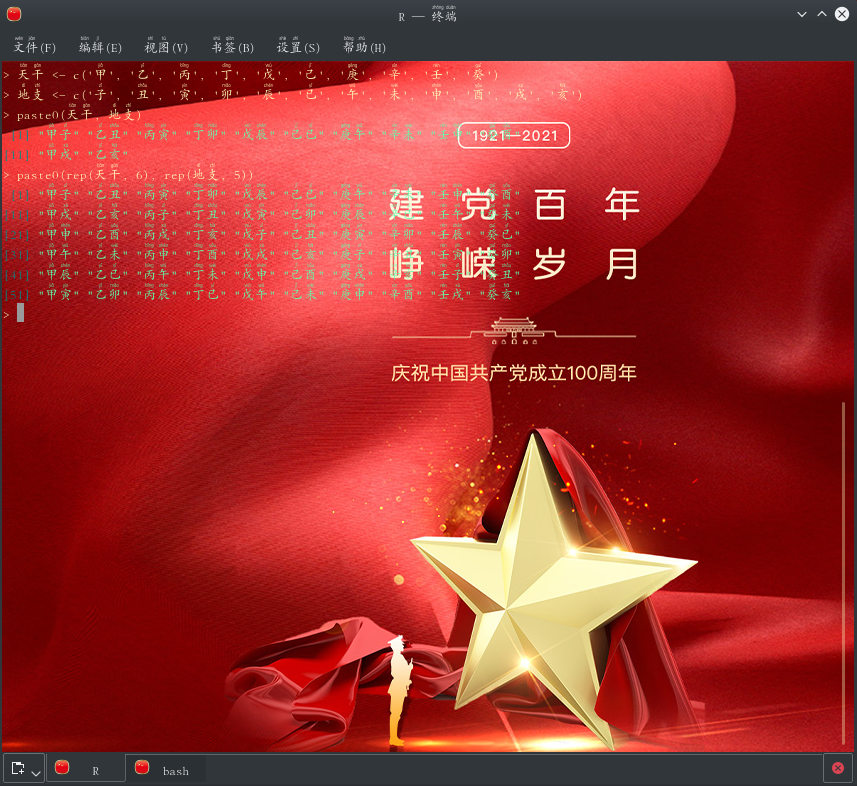

有关农历与二十四节气，目前正在自修中科红旗之礼逆袭红旗操作系统，会先将曦与曦佳佳编程语言翻译为咱们中文编程附上拼音（李斯篆书），再提升为文言文及古文编程、日期均以农历与咱们中华五千多年习俗文化道教为主，它日再研发「大秦赋」操作系统，欲知更多详情请查阅[「猫城」](https://github.com/englianhu/RedFlag-Linux)和[「猫城」](https://github.com/englianhu/library)。

- [我国主要历法及基本原理 古代天文学知识科普（六）](https://www.bilibili.com/video/BV1B64y1M79y)
- [农历纪年法：怎样通过公元纪年推算干支纪年](https://www.sohu.com/a/139120191_372495)
- [「问百度」干支纪年](https://baike.baidu.com/item/%E5%B9%B2%E6%94%AF%E7%BA%AA%E5%B9%B4/3383226)
- [（历法溯源十）天文历法大成，周易天象解密，易经的天象规律](https://www.bilibili.com/video/BV1AA411R7LE)
- [天文课程 - 时间和历法](https://www.bilibili.com/video/BV1uv411K7sd)

#### 5.1.1.2 日内计时法

> … 但其实除了十二时辰之外，古人还有一种计时方式，那便是“百刻制”。所谓「百刻制」指的就是一天等于一百刻，这就是古人常说的「一刻钟」，很多人都认为古代的「一刻钟」等于现代的十五分钟，其实这是一种错误的理解。

> 二、「一刻钟、一炷香、一盏茶」分别指多长时间？ 前文中我们提到了古代的百刻制，意思就是古人将一天的时间，分为了一百刻，其中一刻钟相当于现代的十四分廿四秒，一直到了清朝初期时，才将“百刻制”减为桦六刻，这便是「一刻钟」等于现代的十五分钟的由来…

*引用：[「原创」古人常说的：“一刻钟、一炷香、一盏茶”，分别指多长时间？](https://www.sohu.com/a/663536640_121205324)*

> **题外话**：“刹那”是多久？ 在文章的最后，青年君想用很短的时间和大家稍微唠一唠「很短的时间」——刹那。

> 刹那是古印度佛教术语，也是时间度量单位，表示一念之间的极短时间，随佛教传入中国。据《摩诃僧祇律》记载：“须臾者，二十念名一瞬顷，二十瞬名一弹指，二十弹指名一罗豫，二十罗豫名一须臾。日极长时有十八须臾，夜极短时有十二须臾；夜极长时有十八须臾，日极短时有十二须臾。”

> 一日一夜有卅个须臾，六百个罗豫，一万两千个弹指，廿四万个「瞬间」，四百枯万个「刹那」。据此推算——

> 「须臾」是卌八分钟 「罗豫」是两分钟廿四秒 「弹指」是七点二秒 「瞬顷」是三百圆厘秒 「刹那」是十八厘秒

> 我国古代形成的完整的计时方法和计时制度，是古人在探索时间计量方式上取得的进步、是智慧的结晶。当然，无论如何度量时间，一天就只有廿四小时。盛年不重来，一日难再晨。及时当勉励，岁月不待人。只要我们能善用时间，就永远不愁时间不够用。忘掉今天的人，也终将被明天忘掉。

*引用：[「十二时辰」简史](http://news.ts.cn/system/2019/07/26/035802762.shtml)*

欲以古代计时法来精准筹算咱们「一炷香」和「一盏茶」的话，就得使用隐马尔可夫链模型或其它统计模型筹算气温、空气湿度、空气流动风速、空气中的氢气成分等各种因素可以设置精准到飞秒（fs，十五个小数位）或更精准时间计量单位。

- [一刻钟等于多少分钟（古代一刻钟是多长时间）](https://k.sina.cn/article_2188503504_8271e9d002700woon.html)
- [古代一刻钟是多久？一点钟为什么不是一小时？弄不清会很尴尬的](https://zhuanlan.zhihu.com/p/525032381)
- [一刻钟是多久，古代的一天为几刻钟呢？](https://zhidao.baidu.com/question/16558757)
- [「问百度」一刻钟](https://baike.baidu.com/item/%E4%B8%80%E5%88%BB%E9%92%9F/2070381)

```r
source('函数/日内高频指数平滑.R')
source('函数/汇总上奏.R')
source('函数/总汇结论.R')

时间索引 <- unique(样本$日期)
# 基准 <- filter(样本, 年份 == 2016)$日期[1] #"2016-01-04" 第2年第1个交易日
基准 <- 样本[年份 == 2016]$日期[1]
时间索引 %<>% .[. >= 基准]
# 时间索引 %<>% .[. >= as_date('2016-01-04')]
迭代基准 <- 样本[日期 %chin% 时间索引]$序列
数据量 <- 1200 #筛选数据中的最后1200观测值：样本[(.N - (数据量 - 1)):.N]
预测时间单位 <- 1

.模型选项 = c('MNN')
```

### 5.1.2 十时辰一周期（千皕分钟循环一次）

```r
# --------- eval = FALSE ---------
频率 = 1200

日内高频指数平滑(
     时间索引 = 时间索引, 样本 = 样本, 数据量 = 数据量, 频率 = 频率,
     预测时间单位 = 预测时间单位, .模型选项 = .模型选项)
```

### 5.1.3 五时辰一周期（六百分钟循环两次）

```r
# --------- eval = FALSE ---------
频率 = 600

日内高频指数平滑(
     时间索引 = 时间索引, 样本 = 样本, 数据量 = 数据量, 频率 = 频率,
     预测时间单位 = 预测时间单位, .模型选项 = .模型选项)
```

### 5.1.4 三分之十时辰一周期（四百分钟循环三次）

```r
# --------- eval = FALSE ---------
频率 = 400

日内高频指数平滑(
     时间索引 = 时间索引, 样本 = 样本, 数据量 = 数据量, 频率 = 频率,
     预测时间单位 = 预测时间单位, .模型选项 = .模型选项)
```

### 5.1.5 两时辰半一周期（三百分钟循环四次）

```r
# --------- eval = FALSE ---------
频率 = 300

日内高频指数平滑(
     时间索引 = 时间索引, 样本 = 样本, 数据量 = 数据量, 频率 = 频率,
     预测时间单位 = 预测时间单位, .模型选项 = .模型选项)
```

### 5.1.6 两时辰一周期（皕卌分钟循环五次）

```r
# --------- eval = FALSE ---------
频率 = 240

日内高频指数平滑(
     时间索引 = 时间索引, 样本 = 样本, 数据量 = 数据量, 频率 = 频率,
     预测时间单位 = 预测时间单位, .模型选项 = .模型选项)
```

### 5.1.7 三分之五时辰一周期（皕分钟循环六次）

```r
# --------- eval = FALSE ---------
频率 = 200

日内高频指数平滑(
     时间索引 = 时间索引, 样本 = 样本, 数据量 = 数据量, 频率 = 频率,
     预测时间单位 = 预测时间单位, .模型选项 = .模型选项)
```

### 5.1.8 一时辰两刻钟一周期（百圩分钟循环八次）

```r
# --------- eval = FALSE ---------
频率 = 150

日内高频指数平滑(
     时间索引 = 时间索引, 样本 = 样本, 数据量 = 数据量, 频率 = 频率,
     预测时间单位 = 预测时间单位, .模型选项 = .模型选项)
```

### 5.1.9 一时辰一周期（百廿分钟循环十次）

```r
# --------- eval = FALSE ---------
频率 = 120

日内高频指数平滑(
     时间索引 = 时间索引, 样本 = 样本, 数据量 = 数据量, 频率 = 频率,
     预测时间单位 = 预测时间单位, .模型选项 = .模型选项)
```

### 5.1.10 六分之五时辰一周期（百分钟循环十二次）

```r
# --------- eval = FALSE ---------
频率 = 100

日内高频指数平滑(
     时间索引 = 时间索引, 样本 = 样本, 数据量 = 数据量, 频率 = 频率,
     预测时间单位 = 预测时间单位, .模型选项 = .模型选项)
```

### 5.1.11 三分之二时辰一周期（枯分钟循环十五次）

```r
# --------- eval = FALSE ---------
频率 = 80

日内高频指数平滑(
     时间索引 = 时间索引, 样本 = 样本, 数据量 = 数据量, 频率 = 频率,
     预测时间单位 = 预测时间单位, .模型选项 = .模型选项)
```

### 5.1.12 半时辰一周期（圆分钟循环廿次）

```r
# --------- eval = FALSE ---------
频率 = 60

日内高频指数平滑(
     时间索引 = 时间索引, 样本 = 样本, 数据量 = 数据量, 频率 = 频率,
     预测时间单位 = 预测时间单位, .模型选项 = .模型选项)
```

### 5.1.13 十二分之五时辰一周期（圩分钟循环廿四次）

```r
# --------- eval = FALSE ---------
频率 = 50

日内高频指数平滑(
     时间索引 = 时间索引, 样本 = 样本, 数据量 = 数据量, 频率 = 频率,
     预测时间单位 = 预测时间单位, .模型选项 = .模型选项)
```

### 5.1.14 三分之一时辰一周期（卌分钟循环卅次）

```r
# --------- eval = FALSE ---------
频率 = 40

日内高频指数平滑(
     时间索引 = 时间索引, 样本 = 样本, 数据量 = 数据量, 频率 = 频率,
     预测时间单位 = 预测时间单位, .模型选项 = .模型选项)
```

### 5.1.15 四分之一时辰（两刻钟）一周期（卅分钟循环卌次）

```r
# --------- eval = FALSE ---------
频率 = 30

日内高频指数平滑(
     时间索引 = 时间索引, 样本 = 样本, 数据量 = 数据量, 频率 = 频率,
     预测时间单位 = 预测时间单位, .模型选项 = .模型选项)
```

### 5.1.16 五分之一时辰一周期（廿四分钟循环圩次）

```r
# --------- eval = FALSE ---------
频率 = 24

日内高频指数平滑(
     时间索引 = 时间索引, 样本 = 样本, 数据量 = 数据量, 频率 = 频率,
     预测时间单位 = 预测时间单位, .模型选项 = .模型选项)
```

### 5.1.17 六分之一时辰一周期（廿分钟循环圆次）

```r
# --------- eval = FALSE ---------
频率 = 20

日内高频指数平滑(
     时间索引 = 时间索引, 样本 = 样本, 数据量 = 数据量, 频率 = 频率,
     预测时间单位 = 预测时间单位, .模型选项 = .模型选项)
```

### 5.1.18 十五分之二时辰一周期（十六分钟循环进五次）

```r
# --------- eval = FALSE ---------
频率 = 16

日内高频指数平滑(
     时间索引 = 时间索引, 样本 = 样本, 数据量 = 数据量, 频率 = 频率,
     预测时间单位 = 预测时间单位, .模型选项 = .模型选项)
```

### 5.1.19 八分之一时辰（一刻钟）一周期（十五分钟循环枯次）

```r
# --------- eval = FALSE ---------
频率 = 15

日内高频指数平滑(
     时间索引 = 时间索引, 样本 = 样本, 数据量 = 数据量, 频率 = 频率,
     预测时间单位 = 预测时间单位, .模型选项 = .模型选项)
```

### 5.1.20 十分之一时辰一周期（十二分钟循环百次）

```r
# --------- eval = FALSE ---------
频率 = 12

日内高频指数平滑(
     时间索引 = 时间索引, 样本 = 样本, 数据量 = 数据量, 频率 = 频率,
     预测时间单位 = 预测时间单位, .模型选项 = .模型选项)
```

### 5.1.21 十二分之一时辰（三分之二刻钟）一周期（十分钟循环百廿次）

```r
# --------- eval = FALSE ---------
频率 = 10

日内高频指数平滑(
     时间索引 = 时间索引, 样本 = 样本, 数据量 = 数据量, 频率 = 频率,
     预测时间单位 = 预测时间单位, .模型选项 = .模型选项)
```

### 5.1.22 十五分之一时辰一周期（八分钟循环百圩次）

```r
# --------- eval = FALSE ---------
频率 = 8

日内高频指数平滑(
     时间索引 = 时间索引, 样本 = 样本, 数据量 = 数据量, 频率 = 频率,
     预测时间单位 = 预测时间单位, .模型选项 = .模型选项)
```

### 5.1.23 廿分之一时辰一周期（六分钟循环皕次）

```r
# --------- eval = FALSE ---------
频率 = 6

日内高频指数平滑(
     时间索引 = 时间索引, 样本 = 样本, 数据量 = 数据量, 频率 = 频率,
     预测时间单位 = 预测时间单位, .模型选项 = .模型选项)
```

### 5.1.24 廿四分之一时辰（三分之一刻钟）一周期（五分钟循环皕卌次）

```r
# --------- eval = FALSE ---------
频率 = 5

日内高频指数平滑(
     时间索引 = 时间索引, 样本 = 样本, 数据量 = 数据量, 频率 = 频率,
     预测时间单位 = 预测时间单位, .模型选项 = .模型选项)
```

### 5.1.25 卅分之一时辰一周期（四分钟循环三百次）

```r
# --------- eval = FALSE ---------
频率 = 4

日内高频指数平滑(
     时间索引 = 时间索引, 样本 = 样本, 数据量 = 数据量, 频率 = 频率,
     预测时间单位 = 预测时间单位, .模型选项 = .模型选项)
```

### 5.1.26 卌分之一时辰一周期（三分钟循环四百次）

```r
# --------- eval = FALSE ---------
频率 = 3

日内高频指数平滑(
     时间索引 = 时间索引, 样本 = 样本, 数据量 = 数据量, 频率 = 频率,
     预测时间单位 = 预测时间单位, .模型选项 = .模型选项)
```

### 5.1.27 圆分之一时辰一周期（两分钟循环六百次）

```r
# --------- eval = FALSE ---------
频率 = 2

日内高频指数平滑(
     时间索引 = 时间索引, 样本 = 样本, 数据量 = 数据量, 频率 = 频率,
     预测时间单位 = 预测时间单位, .模型选项 = .模型选项)
```

```r
# --------- eval = FALSE ---------
频率 = 1

日内高频指数平滑(
     时间索引 = 时间索引, 样本 = 样本, 数据量 = 数据量, 频率 = 频率,
     预测时间单位 = 预测时间单位, .模型选项 = .模型选项)
```

# 6 模型比较

## 6.1 三年半载（至二零一八年七月七日）汇价数据

```r
source('函数/汇总上奏.R')
source('函数/总汇结论.R')

if (!exists('.蜀道仓库')) {
  .蜀道仓库 <- paste0(.蜀道, '文艺数据库/fx/USDJPY/仓库/')
}

##
## 这儿先储存数据并列印函数回归结论，省略计算过程，方便日后读取数据。
##
#日内指数平滑数据总汇 <- 汇总上奏()
日内指数平滑数据总汇 <- 汇总上奏(是否储存总汇 = '是')

#日内指数平滑数据结论 <- 总汇结论()
日内指数平滑数据结论 <- 总汇结论(是否储存结论 = '是')

# 日内指数平滑数据总汇 <- readRDS(paste0(.蜀道仓库, '日内指数平滑数据总汇.rds'))

# 日内指数平滑数据结论 <- readRDS(paste0(.蜀道仓库, '日内指数平滑数据结论.rds'))
```

```r
日内指数平滑数据结论 <- readRDS(paste0(.蜀道仓库, '日内指数平滑数据结论.rds'))

## 这儿将精准度调整至30位数，round(..., 30)
日内指数平滑数据结论 %>%
  dplyr::mutate(
    `均对误差（MAE）` = ifelse(
      rank(`均对误差（MAE）`) <= 3,
      cell_spec(
        paste0(round(`均对误差（MAE）`, 30), ' (rank: ', sprintf('%1.f', rank(`均对误差（MAE）`)), ')'),
        color = 'darkgoldenrod', bold = TRUE),
      cell_spec(
        paste0(round(`均对误差（MAE）`, 30), ' (rank: ', sprintf('%1.f', rank(`均对误差（MAE）`)), ')'),
        color = 'grey', italic = TRUE)),

    `均对百分比误差（MAPE）` = ifelse(
      rank(`均对百分比误差（MAPE）`) <= 3,
      cell_spec(
        paste0(round(`均对百分比误差（MAPE）`, 30), ' (rank: ', sprintf('%1.f', rank(`均对百分比误差（MAPE）`)), ')'),
        color = 'darkgoldenrod', bold = TRUE),
      cell_spec(
        paste0(round(`均对百分比误差（MAPE）`, 30), ' (rank: ', sprintf('%1.f', rank(`均对百分比误差（MAPE）`)), ')'),
        color = 'grey', italic = TRUE)),

    `均方根误差（RMSE）` = ifelse(
      rank(`均方根误差（RMSE）`) <= 3,
      cell_spec(
        paste0(round(`均方根误差（RMSE）`, 30), ' (rank: ', sprintf('%1.f', rank(`均方根误差（RMSE）`)), ')'),
        color = 'darkgoldenrod', bold = TRUE),
      cell_spec(
        paste0(round(`均方根误差（RMSE）`, 30), ' (rank: ', sprintf('%1.f', rank(`均方根误差（RMSE）`)), ')'),
        color = 'grey', italic = TRUE)),

    `对称均对百分比误差（SMAPE）` = ifelse(
      rank(`对称均对百分比误差（SMAPE）`) <= 3,
      cell_spec(
        paste0(round(`对称均对百分比误差（SMAPE）`, 30), ' (rank: ', sprintf('%1.f', rank(`对称均对百分比误差（SMAPE）`)), ')'),
        color = 'darkgoldenrod', bold = TRUE),
      cell_spec(
        paste0(round(`对称均对百分比误差（SMAPE）`, 30), ' (rank: ', sprintf('%1.f', rank(`对称均对百分比误差（SMAPE）`)), ')'),
        color = 'grey', italic = TRUE)),

    `均方误差（MSE）` = ifelse(
      rank(`均方误差（MSE）`) <= 3,
      cell_spec(
        paste0(round(`均方误差（MSE）`, 30), ' (rank: ', sprintf('%1.f', rank(`均方误差（MSE）`)), ')'),
        color = 'darkgoldenrod', bold = TRUE),
      cell_spec(
        paste0(round(`均方误差（MSE）`, 30), ' (rank: ', sprintf('%1.f', rank(`均方误差（MSE）`)), ')'),
        color = 'grey', italic = TRUE))) %>%
  kbl(caption = '最优统计模型（三年七个月数据）', escape = FALSE) %>%
  ## https://www.w3schools.com/cssref/css_colors.asp
  row_spec(0, background = 'DimGrey', color = '#7B1113') %>%
  column_spec(1, background = 'CornflowerBlue') %>%
  #column_spec(2, background = '#556DAC') %>%
  column_spec(2, background = 'LightSlateGrey') %>%
  column_spec(3, background = 'LightGray') %>%
  column_spec(4, background = 'Gainsboro') %>%
  column_spec(5, background = 'LightGray') %>%
  column_spec(6, background = 'Gainsboro') %>%
  column_spec(7, background = 'LightGray') %>%
  column_spec(8, background = 'Gainsboro') %>%
  kable_styling(bootstrap_options = c('striped', 'hover', 'condensed', 'responsive')) %>%
  kable_material(full_width = FALSE) %>%
  scroll_box(width = '100%', fixed_thead = TRUE, height = '500px')
```

最优统计模型（三年七个月数据）

| 频率 | 频率（分计） | 均对误差（MAE） | 均对百分比误差（MAPE） | 均方根误差（RMSE） | 对称均对百分比误差（SMAPE） | 均方误差（MSE） | 平均绝对比例误差（MASE） |
| --- | --- | --- | --- | --- | --- | --- | --- |
| 1 | 943199 | 0.0125598132280382 (rank: 1) | 0.000113956574981373 (rank: 1) | 0.0275052907700786 (rank: 1) | 0.000113956280028935 (rank: 1) | 0.000756541020346569 (rank: 1) | NA |
| 2 | 943199 | 0.0125598275856001 (rank: 2) | 0.000113956702398221 (rank: 2) | 0.0275053154699935 (rank: 2) | 0.000113956407392248 (rank: 2) | 0.000756542379103862 (rank: 2) | NA |
| 3 | 943199 | 0.0125598324341063 (rank: 3) | 0.0001139567454243 (rank: 3) | 0.0275053243448574 (rank: 3) | 0.000113956450399092 (rank: 3) | 0.000756542867315803 (rank: 3) | NA |
| 4 | 943199 | 0.0125598348699095 (rank: 4) | 0.000113956767039434 (rank: 4) | 0.0275053289030394 (rank: 4) | 0.000113956472004346 (rank: 4) | 0.000756543118064375 (rank: 4) | NA |
| 5 | 943199 | 0.0125598363353092 (rank: 5) | 0.000113956780043145 (rank: 5) | 0.0275053316766579 (rank: 5) | 0.000113956485002045 (rank: 5) | 0.000756543270642961 (rank: 5) | NA |
| 6 | 943199 | 0.0125598373138901 (rank: 6) | 0.000113956788726849 (rank: 6) | 0.0275053335418821 (rank: 6) | 0.000113956493681708 (rank: 6) | 0.000756543373250184 (rank: 6) | NA |
| 8 | 943199 | 0.0125598385389828 (rank: 7) | 0.00011395679959798 (rank: 7) | 0.02750533589159 (rank: 7) | 0.000113956504547745 (rank: 7) | 0.00075654350250919 (rank: 7) | NA |
| 10 | 943199 | 0.0125598392750393 (rank: 8) | 0.000113956806129506 (rank: 8) | 0.0275053373111159 (rank: 8) | 0.000113956511076195 (rank: 8) | 0.000756543580598262 (rank: 8) | NA |
| 12 | 943200 | 0.0125598996228494 (rank: 27) | 0.00011395733688368 (rank: 27) | 0.0275054154836054 (rank: 27) | 0.000113957041631135 (rank: 27) | 0.000756547880925759 (rank: 27) | NA |
| 15 | 943199 | 0.0125598402576223 (rank: 9) | 0.000113956814848585 (rank: 9) | 0.027505339215142 (rank: 9) | 0.000113956519791148 (rank: 9) | 0.000756543685340028 (rank: 9) | NA |
| 16 | 943199 | 0.0125598403805398 (rank: 10) | 0.000113956815939307 (rank: 10) | 0.0275053394540557 (rank: 10) | 0.000113956520881352 (rank: 10) | 0.000756543698482831 (rank: 10) | NA |
| 20 | 943199 | 0.012559840749419 (rank: 11) | 0.000113956819212591 (rank: 11) | 0.0275053401720112 (rank: 11) | 0.00011395652415308 (rank: 11) | 0.000756543737978053 (rank: 11) | NA |
| 24 | 943199 | 0.012559840995444 (rank: 12) | 0.000113956821395714 (rank: 12) | 0.0275053406516602 (rank: 12) | 0.000113956526335164 (rank: 12) | 0.000756543764363873 (rank: 12) | NA |
| 30 | 943199 | 0.0125598412415537 (rank: 13) | 0.000113956823579585 (rank: 13) | 0.0275053411321192 (rank: 13) | 0.000113956528517993 (rank: 13) | 0.000756543790794247 (rank: 13) | NA |
| 40 | 943199 | 0.0125598414877481 (rank: 14) | 0.000113956825764205 (rank: 14) | 0.0275053416133881 (rank: 14) | 0.00011395653070157 (rank: 14) | 0.00075654381726918 (rank: 14) | NA |
| 50 | 943199 | 0.0125598416355055 (rank: 15) | 0.000113956827075337 (rank: 15) | 0.0275053419025383 (rank: 15) | 0.000113956532012075 (rank: 15) | 0.00075654383317553 (rank: 15) | NA |
| 60 | 943199 | 0.0125598417340274 (rank: 16) | 0.000113956827949575 (rank: 16) | 0.0275053420954672 (rank: 16) | 0.000113956532885895 (rank: 16) | 0.000756543843788678 (rank: 16) | NA |
| 80 | 943199 | 0.0125598418571989 (rank: 17) | 0.000113956829042541 (rank: 17) | 0.0275053423368104 (rank: 17) | 0.000113956533978339 (rank: 17) | 0.000756543857065135 (rank: 17) | NA |
| 100 | 943199 | 0.0125598419311119 (rank: 18) | 0.000113956829698411 (rank: 18) | 0.0275053424817138 (rank: 18) | 0.000113956534633894 (rank: 18) | 0.000756543865036367 (rank: 18) | NA |
| 120 | 943199 | 0.0125598419803916 (rank: 19) | 0.000113956830135696 (rank: 19) | 0.0275053425783564 (rank: 19) | 0.000113956535070969 (rank: 19) | 0.000756543870352747 (rank: 19) | NA |
| 150 | 943199 | 0.0125598420296746 (rank: 20) | 0.00011395683057301 (rank: 20) | 0.0275053426750315 (rank: 20) | 0.000113956535508074 (rank: 20) | 0.000756543875670908 (rank: 20) | NA |
| 200 | 943199 | 0.0125598420789611 (rank: 21) | 0.000113956831010354 (rank: 21) | 0.0275053427717391 (rank: 21) | 0.000113956535945209 (rank: 21) | 0.000756543880990858 (rank: 21) | NA |
| 240 | 943199 | 0.0125598421036242 (rank: 22) | 0.000113956831229203 (rank: 22) | 0.0275053428201053 (rank: 22) | 0.000113956536163953 (rank: 22) | 0.000756543883651516 (rank: 22) | NA |
| 300 | 943199 | 0.0125598421282681 (rank: 23) | 0.000113956831447881 (rank: 23) | 0.0275053428684793 (rank: 23) | 0.000113956536382526 (rank: 23) | 0.000756543886312606 (rank: 23) | NA |
| 400 | 943199 | 0.0125598421529131 (rank: 24) | 0.000113956831666568 (rank: 24) | 0.0275053429168613 (rank: 24) | 0.000113956536601108 (rank: 24) | 0.000756543888974132 (rank: 24) | NA |
| 600 | 943199 | 0.0125598421775588 (rank: 25) | 0.000113956831885262 (rank: 25) | 0.0275053429652516 (rank: 25) | 0.000113956536819698 (rank: 25) | 0.000756543891636114 (rank: 25) | NA |
| 1200 | 943199 | 0.0125598422022052 (rank: 26) | 0.000113956832103963 (rank: 26) | 0.0275053430136499 (rank: 26) | 0.000113956537038294 (rank: 26) | 0.00075654389429854 (rank: 26) | NA |

*数据：27 x 8*

## 6.2 一年汇价数据

### 6.2.1 一年总汇数据

为了方便日后节省时间，这儿过滤一年汇价数据。

```r
source('函数/汇总上奏.R')
source('函数/总汇结论.R')

## A data.table and dplyr tour
## https://atrebas.github.io/post/2019-03-03-datatable-dplyr/#addupdatedelete-columns
日内指数平滑数据总汇 <- fread(paste0(.蜀道仓库, '日内指数平滑数据总汇.csv'))
日内指数平滑数据总汇[, 年份 := data.table::year(年月日时分)]
日内指数平滑数据二零一六年总汇 <- 日内指数平滑数据总汇[年份 == 2016]
# saveRDS(日内指数平滑数据二零一六年总汇, paste0(.蜀道仓库, '日内指数平滑数据二零一六年总汇.rds'))
日内指数平滑数据二零一七年总汇 <- 日内指数平滑数据总汇[年份 == 2017]
# saveRDS(日内指数平滑数据二零一七年总汇, paste0(.蜀道仓库, '日内指数平滑数据二零一七年总汇.rds'))
日内指数平滑数据二零一八年总汇 <- 日内指数平滑数据总汇[年份 == 2018]
# saveRDS(日内指数平滑数据二零一八年总汇, paste0(.蜀道仓库, '日内指数平滑数据二零一八年总汇.rds'))
日内指数平滑数据二零一八年上半年总汇 <- 日内指数平滑数据二零一八年总汇[, 月份 := data.table::month(年月日时分)][月份 %chin% 1:6]
# saveRDS(日内指数平滑数据二零一八年上半年总汇, paste0(.蜀道仓库, '日内指数平滑数据二零一八年上半年总汇.rds'))

# 日内指数平滑数据二零一六年结论 <- 总汇结论(总汇 = 日内指数平滑数据二零一六年总汇, 文件名 = '日内指数平滑数据二零一六年', 是否储存结论 = '是')
日内指数平滑数据二零一六年结论 <- readRDS(paste0(.蜀道仓库, '日内指数平滑数据二零一六年结论.rds'))

# 日内指数平滑数据二零一七年结论 <- 总汇结论(总汇 = 日内指数平滑数据二零一七年总汇, 文件名 = '日内指数平滑数据二零一七年', 是否储存结论 = '是')
日内指数平滑数据二零一七年结论 <- readRDS(paste0(.蜀道仓库, '日内指数平滑数据二零一七年结论.rds'))

# 日内指数平滑数据二零一八年结论 <- 总汇结论(总汇 = 日内指数平滑数据二零一八年总汇, 文件名 = '日内指数平滑数据二零一八年', 是否储存结论 = '是')
日内指数平滑数据二零一八年结论 <- readRDS(paste0(.蜀道仓库, '日内指数平滑数据二零一八年结论.rds'))

# 日内指数平滑数据二零一八年上半年结论 <- 总汇结论(总汇 = 日内指数平滑数据二零一八年上半年总汇, 文件名 = '日内指数平滑数据二零一八年上半年', 是否储存结论 = '是')
日内指数平滑数据二零一八年上半年结论 <- readRDS(paste0(.蜀道仓库, '日内指数平滑数据二零一八年上半年结论.rds'))
```

### 6.2.2 总汇二零一六年结论

```r
## 这儿将精准度调整至30位数，round(..., 30)
日内指数平滑数据二零一六年结论 %>%
  dplyr::mutate(
    `均对误差（MAE）` = ifelse(
      rank(`均对误差（MAE）`) <= 3,
      cell_spec(
        paste0(round(`均对误差（MAE）`, 30), ' (rank: ', sprintf('%1.f', rank(`均对误差（MAE）`)), ')'),
        color = 'darkgoldenrod', bold = TRUE),
      cell_spec(
        paste0(round(`均对误差（MAE）`, 30), ' (rank: ', sprintf('%1.f', rank(`均对误差（MAE）`)), ')'),
        color = 'grey', italic = TRUE)),

    `均对百分比误差（MAPE）` = ifelse(
      rank(`均对百分比误差（MAPE）`) <= 3,
      cell_spec(
        paste0(round(`均对百分比误差（MAPE）`, 30), ' (rank: ', sprintf('%1.f', rank(`均对百分比误差（MAPE）`)), ')'),
        color = 'darkgoldenrod', bold = TRUE),
      cell_spec(
        paste0(round(`均对百分比误差（MAPE）`, 30), ' (rank: ', sprintf('%1.f', rank(`均对百分比误差（MAPE）`)), ')'),
        color = 'grey', italic = TRUE)),

    `均方根误差（RMSE）` = ifelse(
      rank(`均方根误差（RMSE）`) <= 3,
      cell_spec(
        paste0(round(`均方根误差（RMSE）`, 30), ' (rank: ', sprintf('%1.f', rank(`均方根误差（RMSE）`)), ')'),
        color = 'darkgoldenrod', bold = TRUE),
      cell_spec(
        paste0(round(`均方根误差（RMSE）`, 30), ' (rank: ', sprintf('%1.f', rank(`均方根误差（RMSE）`)), ')'),
        color = 'grey', italic = TRUE)),

    `对称均对百分比误差（SMAPE）` = ifelse(
      rank(`对称均对百分比误差（SMAPE）`) <= 3,
      cell_spec(
        paste0(round(`对称均对百分比误差（SMAPE）`, 30), ' (rank: ', sprintf('%1.f', rank(`对称均对百分比误差（SMAPE）`)), ')'),
        color = 'darkgoldenrod', bold = TRUE),
      cell_spec(
        paste0(round(`对称均对百分比误差（SMAPE）`, 30), ' (rank: ', sprintf('%1.f', rank(`对称均对百分比误差（SMAPE）`)), ')'),
        color = 'grey', italic = TRUE)),

    `均方误差（MSE）` = ifelse(
      rank(`均方误差（MSE）`) <= 3,
      cell_spec(
        paste0(round(`均方误差（MSE）`, 30), ' (rank: ', sprintf('%1.f', rank(`均方误差（MSE）`)), ')'),
        color = 'darkgoldenrod', bold = TRUE),
      cell_spec(
        paste0(round(`均方误差（MSE）`, 30), ' (rank: ', sprintf('%1.f', rank(`均方误差（MSE）`)), ')'),
        color = 'grey', italic = TRUE))) %>%
  kbl(caption = '最优统计模型（二零一六年总汇）', escape = FALSE) %>%
  ## https://www.w3schools.com/cssref/css_colors.asp
  row_spec(0, background = 'DimGrey', color = '#7B1113') %>%
  column_spec(1, background = 'CornflowerBlue') %>%
  #column_spec(2, background = '#556DAC') %>%
  column_spec(2, background = 'LightSlateGrey') %>%
  column_spec(3, background = 'LightGray') %>%
  column_spec(4, background = 'Gainsboro') %>%
  column_spec(5, background = 'LightGray') %>%
  column_spec(6, background = 'Gainsboro') %>%
  column_spec(7, background = 'LightGray') %>%
  column_spec(8, background = 'Gainsboro') %>%
  kable_styling(bootstrap_options = c('striped', 'hover', 'condensed', 'responsive')) %>%
  kable_material(full_width = FALSE) %>%
  scroll_box(width = '100%', fixed_thead = TRUE, height = '500px')
```

最优统计模型（二零一六年总汇）

| 频率 | 频率（分计） | 均对误差（MAE） | 均对百分比误差（MAPE） | 均方根误差（RMSE） | 对称均对百分比误差（SMAPE） | 均方误差（MSE） | 平均绝对比例误差（MASE） |
| --- | --- | --- | --- | --- | --- | --- | --- |
| 1 | 374399 | 0.0135734298195191 (rank: 14) | 0.000124789289334461 (rank: 14) | 0.0235665011094028 (rank: 14) | 0.000124787384073848 (rank: 14) | 0.000555379974539485 (rank: 14) | NA |
| 2 | 374399 | 0.0135734298195191 (rank: 14) | 0.000124789289334461 (rank: 14) | 0.0235665011094028 (rank: 14) | 0.000124787384073848 (rank: 14) | 0.000555379974539485 (rank: 14) | NA |
| 3 | 374399 | 0.0135734298195191 (rank: 14) | 0.000124789289334461 (rank: 14) | 0.0235665011094028 (rank: 14) | 0.000124787384073848 (rank: 14) | 0.000555379974539485 (rank: 14) | NA |
| 4 | 374399 | 0.0135734298195191 (rank: 14) | 0.000124789289334461 (rank: 14) | 0.0235665011094028 (rank: 14) | 0.000124787384073848 (rank: 14) | 0.000555379974539485 (rank: 14) | NA |
| 5 | 374399 | 0.0135734298195191 (rank: 14) | 0.000124789289334461 (rank: 14) | 0.0235665011094028 (rank: 14) | 0.000124787384073848 (rank: 14) | 0.000555379974539485 (rank: 14) | NA |
| 6 | 374399 | 0.0135734298195191 (rank: 14) | 0.000124789289334461 (rank: 14) | 0.0235665011094028 (rank: 14) | 0.000124787384073848 (rank: 14) | 0.000555379974539485 (rank: 14) | NA |
| 8 | 374399 | 0.0135734298195191 (rank: 14) | 0.000124789289334461 (rank: 14) | 0.0235665011094028 (rank: 14) | 0.000124787384073848 (rank: 14) | 0.000555379974539485 (rank: 14) | NA |
| 10 | 374399 | 0.0135734298195191 (rank: 14) | 0.000124789289334461 (rank: 14) | 0.0235665011094028 (rank: 14) | 0.000124787384073848 (rank: 14) | 0.000555379974539485 (rank: 14) | NA |
| 12 | 374399 | 0.0135734298195191 (rank: 14) | 0.000124789289334461 (rank: 14) | 0.0235665011094028 (rank: 14) | 0.000124787384073848 (rank: 14) | 0.000555379974539485 (rank: 14) | NA |
| 15 | 374399 | 0.0135734298195191 (rank: 14) | 0.000124789289334461 (rank: 14) | 0.0235665011094028 (rank: 14) | 0.000124787384073848 (rank: 14) | 0.000555379974539485 (rank: 14) | NA |
| 16 | 374399 | 0.0135734298195191 (rank: 14) | 0.000124789289334461 (rank: 14) | 0.0235665011094028 (rank: 14) | 0.000124787384073848 (rank: 14) | 0.000555379974539485 (rank: 14) | NA |
| 20 | 374399 | 0.0135734298195191 (rank: 14) | 0.000124789289334461 (rank: 14) | 0.0235665011094028 (rank: 14) | 0.000124787384073848 (rank: 14) | 0.000555379974539485 (rank: 14) | NA |
| 24 | 374399 | 0.0135734298195191 (rank: 14) | 0.000124789289334461 (rank: 14) | 0.0235665011094028 (rank: 14) | 0.000124787384073848 (rank: 14) | 0.000555379974539485 (rank: 14) | NA |
| 30 | 374399 | 0.0135734298195191 (rank: 14) | 0.000124789289334461 (rank: 14) | 0.0235665011094028 (rank: 14) | 0.000124787384073848 (rank: 14) | 0.000555379974539485 (rank: 14) | NA |
| 40 | 374399 | 0.0135734298195191 (rank: 14) | 0.000124789289334461 (rank: 14) | 0.0235665011094028 (rank: 14) | 0.000124787384073848 (rank: 14) | 0.000555379974539485 (rank: 14) | NA |
| 50 | 374399 | 0.0135734298195191 (rank: 14) | 0.000124789289334461 (rank: 14) | 0.0235665011094028 (rank: 14) | 0.000124787384073848 (rank: 14) | 0.000555379974539485 (rank: 14) | NA |
| 60 | 374399 | 0.0135734298195191 (rank: 14) | 0.000124789289334461 (rank: 14) | 0.0235665011094028 (rank: 14) | 0.000124787384073848 (rank: 14) | 0.000555379974539485 (rank: 14) | NA |
| 80 | 374399 | 0.0135734298195191 (rank: 14) | 0.000124789289334461 (rank: 14) | 0.0235665011094028 (rank: 14) | 0.000124787384073848 (rank: 14) | 0.000555379974539485 (rank: 14) | NA |
| 100 | 374399 | 0.0135734298195191 (rank: 14) | 0.000124789289334461 (rank: 14) | 0.0235665011094028 (rank: 14) | 0.000124787384073848 (rank: 14) | 0.000555379974539485 (rank: 14) | NA |
| 120 | 374399 | 0.0135734298195191 (rank: 14) | 0.000124789289334461 (rank: 14) | 0.0235665011094028 (rank: 14) | 0.000124787384073848 (rank: 14) | 0.000555379974539485 (rank: 14) | NA |
| 150 | 374399 | 0.0135734298195191 (rank: 14) | 0.000124789289334461 (rank: 14) | 0.0235665011094028 (rank: 14) | 0.000124787384073848 (rank: 14) | 0.000555379974539485 (rank: 14) | NA |
| 200 | 374399 | 0.0135734298195191 (rank: 14) | 0.000124789289334461 (rank: 14) | 0.0235665011094028 (rank: 14) | 0.000124787384073848 (rank: 14) | 0.000555379974539485 (rank: 14) | NA |
| 240 | 374399 | 0.0135734298195191 (rank: 14) | 0.000124789289334461 (rank: 14) | 0.0235665011094028 (rank: 14) | 0.000124787384073848 (rank: 14) | 0.000555379974539485 (rank: 14) | NA |
| 300 | 374399 | 0.0135734298195191 (rank: 14) | 0.000124789289334461 (rank: 14) | 0.0235665011094028 (rank: 14) | 0.000124787384073848 (rank: 14) | 0.000555379974539485 (rank: 14) | NA |
| 400 | 374399 | 0.0135734298195191 (rank: 14) | 0.000124789289334461 (rank: 14) | 0.0235665011094028 (rank: 14) | 0.000124787384073848 (rank: 14) | 0.000555379974539485 (rank: 14) | NA |
| 600 | 374399 | 0.0135734298195191 (rank: 14) | 0.000124789289334461 (rank: 14) | 0.0235665011094028 (rank: 14) | 0.000124787384073848 (rank: 14) | 0.000555379974539485 (rank: 14) | NA |
| 1200 | 374399 | 0.0135734298195191 (rank: 14) | 0.000124789289334461 (rank: 14) | 0.0235665011094028 (rank: 14) | 0.000124787384073848 (rank: 14) | 0.000555379974539485 (rank: 14) | NA |

*数据：27 x 8*

### 6.2.3 总汇二零一七年结论

```r
## 这儿将精准度调整至30位数，round(..., 30)
日内指数平滑数据二零一七年结论 %>%
  dplyr::mutate(
    `均对误差（MAE）` = ifelse(
      rank(`均对误差（MAE）`) <= 3,
      cell_spec(
        paste0(round(`均对误差（MAE）`, 30), ' (rank: ', sprintf('%1.f', rank(`均对误差（MAE）`)), ')'),
        color = 'darkgoldenrod', bold = TRUE),
      cell_spec(
        paste0(round(`均对误差（MAE）`, 30), ' (rank: ', sprintf('%1.f', rank(`均对误差（MAE）`)), ')'),
        color = 'grey', italic = TRUE)),

    `均对百分比误差（MAPE）` = ifelse(
      rank(`均对百分比误差（MAPE）`) <= 3,
      cell_spec(
        paste0(round(`均对百分比误差（MAPE）`, 30), ' (rank: ', sprintf('%1.f', rank(`均对百分比误差（MAPE）`)), ')'),
        color = 'darkgoldenrod', bold = TRUE),
      cell_spec(
        paste0(round(`均对百分比误差（MAPE）`, 30), ' (rank: ', sprintf('%1.f', rank(`均对百分比误差（MAPE）`)), ')'),
        color = 'grey', italic = TRUE)),

    `均方根误差（RMSE）` = ifelse(
      rank(`均方根误差（RMSE）`) <= 3,
      cell_spec(
        paste0(round(`均方根误差（RMSE）`, 30), ' (rank: ', sprintf('%1.f', rank(`均方根误差（RMSE）`)), ')'),
        color = 'darkgoldenrod', bold = TRUE),
      cell_spec(
        paste0(round(`均方根误差（RMSE）`, 30), ' (rank: ', sprintf('%1.f', rank(`均方根误差（RMSE）`)), ')'),
        color = 'grey', italic = TRUE)),

    `对称均对百分比误差（SMAPE）` = ifelse(
      rank(`对称均对百分比误差（SMAPE）`) <= 3,
      cell_spec(
        paste0(round(`对称均对百分比误差（SMAPE）`, 30), ' (rank: ', sprintf('%1.f', rank(`对称均对百分比误差（SMAPE）`)), ')'),
        color = 'darkgoldenrod', bold = TRUE),
      cell_spec(
        paste0(round(`对称均对百分比误差（SMAPE）`, 30), ' (rank: ', sprintf('%1.f', rank(`对称均对百分比误差（SMAPE）`)), ')'),
        color = 'grey', italic = TRUE)),

    `均方误差（MSE）` = ifelse(
      rank(`均方误差（MSE）`) <= 3,
      cell_spec(
        paste0(round(`均方误差（MSE）`, 30), ' (rank: ', sprintf('%1.f', rank(`均方误差（MSE）`)), ')'),
        color = 'darkgoldenrod', bold = TRUE),
      cell_spec(
        paste0(round(`均方误差（MSE）`, 30), ' (rank: ', sprintf('%1.f', rank(`均方误差（MSE）`)), ')'),
        color = 'grey', italic = TRUE))) %>%
  kbl(caption = '最优统计模型（二零一七年总汇）', escape = FALSE) %>%
  ## https://www.w3schools.com/cssref/css_colors.asp
  row_spec(0, background = 'DimGrey', color = '#7B1113') %>%
  column_spec(1, background = 'CornflowerBlue') %>%
  #column_spec(2, background = '#556DAC') %>%
  column_spec(2, background = 'LightSlateGrey') %>%
  column_spec(3, background = 'LightGray') %>%
  column_spec(4, background = 'Gainsboro') %>%
  column_spec(5, background = 'LightGray') %>%
  column_spec(6, background = 'Gainsboro') %>%
  column_spec(7, background = 'LightGray') %>%
  column_spec(8, background = 'Gainsboro') %>%
  kable_styling(bootstrap_options = c('striped', 'hover', 'condensed', 'responsive')) %>%
  kable_material(full_width = FALSE) %>%
  scroll_box(width = '100%', fixed_thead = TRUE, height = '500px')
```

最优统计模型（二零一七年总汇）

| 频率 | 频率（分计） | 均对误差（MAE） | 均对百分比误差（MAPE） | 均方根误差（RMSE） | 对称均对百分比误差（SMAPE） | 均方误差（MSE） | 平均绝对比例误差（MASE） |
| --- | --- | --- | --- | --- | --- | --- | --- |
| 1 | 374401 | 0.010337203260825 (rank: 14) | 9.21034936300138e-05 (rank: 14) | 0.0166214301032799 (rank: 14) | 9.21033974708097e-05 (rank: 14) | 0.000276271938678218 (rank: 14) | NA |
| 2 | 374401 | 0.010337203260825 (rank: 14) | 9.21034936300138e-05 (rank: 14) | 0.0166214301032799 (rank: 14) | 9.21033974708097e-05 (rank: 14) | 0.000276271938678218 (rank: 14) | NA |
| 3 | 374401 | 0.010337203260825 (rank: 14) | 9.21034936300138e-05 (rank: 14) | 0.0166214301032799 (rank: 14) | 9.21033974708097e-05 (rank: 14) | 0.000276271938678218 (rank: 14) | NA |
| 4 | 374401 | 0.010337203260825 (rank: 14) | 9.21034936300138e-05 (rank: 14) | 0.0166214301032799 (rank: 14) | 9.21033974708097e-05 (rank: 14) | 0.000276271938678218 (rank: 14) | NA |
| 5 | 374401 | 0.010337203260825 (rank: 14) | 9.21034936300138e-05 (rank: 14) | 0.0166214301032799 (rank: 14) | 9.21033974708097e-05 (rank: 14) | 0.000276271938678218 (rank: 14) | NA |
| 6 | 374401 | 0.010337203260825 (rank: 14) | 9.21034936300138e-05 (rank: 14) | 0.0166214301032799 (rank: 14) | 9.21033974708097e-05 (rank: 14) | 0.000276271938678218 (rank: 14) | NA |
| 8 | 374401 | 0.010337203260825 (rank: 14) | 9.21034936300138e-05 (rank: 14) | 0.0166214301032799 (rank: 14) | 9.21033974708097e-05 (rank: 14) | 0.000276271938678218 (rank: 14) | NA |
| 10 | 374401 | 0.010337203260825 (rank: 14) | 9.21034936300138e-05 (rank: 14) | 0.0166214301032799 (rank: 14) | 9.21033974708097e-05 (rank: 14) | 0.000276271938678218 (rank: 14) | NA |
| 12 | 374401 | 0.010337203260825 (rank: 14) | 9.21034936300138e-05 (rank: 14) | 0.0166214301032799 (rank: 14) | 9.21033974708097e-05 (rank: 14) | 0.000276271938678218 (rank: 14) | NA |
| 15 | 374401 | 0.010337203260825 (rank: 14) | 9.21034936300138e-05 (rank: 14) | 0.0166214301032799 (rank: 14) | 9.21033974708097e-05 (rank: 14) | 0.000276271938678218 (rank: 14) | NA |
| 16 | 374401 | 0.010337203260825 (rank: 14) | 9.21034936300138e-05 (rank: 14) | 0.0166214301032799 (rank: 14) | 9.21033974708097e-05 (rank: 14) | 0.000276271938678218 (rank: 14) | NA |
| 20 | 374401 | 0.010337203260825 (rank: 14) | 9.21034936300138e-05 (rank: 14) | 0.0166214301032799 (rank: 14) | 9.21033974708097e-05 (rank: 14) | 0.000276271938678218 (rank: 14) | NA |
| 24 | 374401 | 0.010337203260825 (rank: 14) | 9.21034936300138e-05 (rank: 14) | 0.0166214301032799 (rank: 14) | 9.21033974708097e-05 (rank: 14) | 0.000276271938678218 (rank: 14) | NA |
| 30 | 374401 | 0.010337203260825 (rank: 14) | 9.21034936300138e-05 (rank: 14) | 0.0166214301032799 (rank: 14) | 9.21033974708097e-05 (rank: 14) | 0.000276271938678218 (rank: 14) | NA |
| 40 | 374401 | 0.010337203260825 (rank: 14) | 9.21034936300138e-05 (rank: 14) | 0.0166214301032799 (rank: 14) | 9.21033974708097e-05 (rank: 14) | 0.000276271938678218 (rank: 14) | NA |
| 50 | 374401 | 0.010337203260825 (rank: 14) | 9.21034936300138e-05 (rank: 14) | 0.0166214301032799 (rank: 14) | 9.21033974708097e-05 (rank: 14) | 0.000276271938678218 (rank: 14) | NA |
| 60 | 374401 | 0.010337203260825 (rank: 14) | 9.21034936300138e-05 (rank: 14) | 0.0166214301032799 (rank: 14) | 9.21033974708097e-05 (rank: 14) | 0.000276271938678218 (rank: 14) | NA |
| 80 | 374401 | 0.010337203260825 (rank: 14) | 9.21034936300138e-05 (rank: 14) | 0.0166214301032799 (rank: 14) | 9.21033974708097e-05 (rank: 14) | 0.000276271938678218 (rank: 14) | NA |
| 100 | 374401 | 0.010337203260825 (rank: 14) | 9.21034936300138e-05 (rank: 14) | 0.0166214301032799 (rank: 14) | 9.21033974708097e-05 (rank: 14) | 0.000276271938678218 (rank: 14) | NA |
| 120 | 374401 | 0.010337203260825 (rank: 14) | 9.21034936300138e-05 (rank: 14) | 0.0166214301032799 (rank: 14) | 9.21033974708097e-05 (rank: 14) | 0.000276271938678218 (rank: 14) | NA |
| 150 | 374401 | 0.010337203260825 (rank: 14) | 9.21034936300138e-05 (rank: 14) | 0.0166214301032799 (rank: 14) | 9.21033974708097e-05 (rank: 14) | 0.000276271938678218 (rank: 14) | NA |
| 200 | 374401 | 0.010337203260825 (rank: 14) | 9.21034936300138e-05 (rank: 14) | 0.0166214301032799 (rank: 14) | 9.21033974708097e-05 (rank: 14) | 0.000276271938678218 (rank: 14) | NA |
| 240 | 374401 | 0.010337203260825 (rank: 14) | 9.21034936300138e-05 (rank: 14) | 0.0166214301032799 (rank: 14) | 9.21033974708097e-05 (rank: 14) | 0.000276271938678218 (rank: 14) | NA |
| 300 | 374401 | 0.010337203260825 (rank: 14) | 9.21034936300138e-05 (rank: 14) | 0.0166214301032799 (rank: 14) | 9.21033974708097e-05 (rank: 14) | 0.000276271938678218 (rank: 14) | NA |
| 400 | 374401 | 0.010337203260825 (rank: 14) | 9.21034936300138e-05 (rank: 14) | 0.0166214301032799 (rank: 14) | 9.21033974708097e-05 (rank: 14) | 0.000276271938678218 (rank: 14) | NA |
| 600 | 374401 | 0.010337203260825 (rank: 14) | 9.21034936300138e-05 (rank: 14) | 0.0166214301032799 (rank: 14) | 9.21033974708097e-05 (rank: 14) | 0.000276271938678218 (rank: 14) | NA |
| 1200 | 374401 | 0.010337203260825 (rank: 14) | 9.21034936300138e-05 (rank: 14) | 0.0166214301032799 (rank: 14) | 9.21033974708097e-05 (rank: 14) | 0.000276271938678218 (rank: 14) | NA |

*数据：27 x 8*

### 6.2.4 总汇二零一八年（至七月七日）结论

```r
## 这儿将精准度调整至30位数，round(..., 30)
日内指数平滑数据二零一八年结论 %>%
  dplyr::mutate(
    `均对误差（MAE）` = ifelse(
      rank(`均对误差（MAE）`) <= 3,
      cell_spec(
        paste0(round(`均对误差（MAE）`, 30), ' (rank: ', sprintf('%1.f', rank(`均对误差（MAE）`)), ')'),
        color = 'darkgoldenrod', bold = TRUE),
      cell_spec(
        paste0(round(`均对误差（MAE）`, 30), ' (rank: ', sprintf('%1.f', rank(`均对误差（MAE）`)), ')'),
        color = 'grey', italic = TRUE)),

    `均对百分比误差（MAPE）` = ifelse(
      rank(`均对百分比误差（MAPE）`) <= 3,
      cell_spec(
        paste0(round(`均对百分比误差（MAPE）`, 30), ' (rank: ', sprintf('%1.f', rank(`均对百分比误差（MAPE）`)), ')'),
        color = 'darkgoldenrod', bold = TRUE),
      cell_spec(
        paste0(round(`均对百分比误差（MAPE）`, 30), ' (rank: ', sprintf('%1.f', rank(`均对百分比误差（MAPE）`)), ')'),
        color = 'grey', italic = TRUE)),

    `均方根误差（RMSE）` = ifelse(
      rank(`均方根误差（RMSE）`) <= 3,
      cell_spec(
        paste0(round(`均方根误差（RMSE）`, 30), ' (rank: ', sprintf('%1.f', rank(`均方根误差（RMSE）`)), ')'),
        color = 'darkgoldenrod', bold = TRUE),
      cell_spec(
        paste0(round(`均方根误差（RMSE）`, 30), ' (rank: ', sprintf('%1.f', rank(`均方根误差（RMSE）`)), ')'),
        color = 'grey', italic = TRUE)),

    `对称均对百分比误差（SMAPE）` = ifelse(
      rank(`对称均对百分比误差（SMAPE）`) <= 3,
      cell_spec(
        paste0(round(`对称均对百分比误差（SMAPE）`, 30), ' (rank: ', sprintf('%1.f', rank(`对称均对百分比误差（SMAPE）`)), ')'),
        color = 'darkgoldenrod', bold = TRUE),
      cell_spec(
        paste0(round(`对称均对百分比误差（SMAPE）`, 30), ' (rank: ', sprintf('%1.f', rank(`对称均对百分比误差（SMAPE）`)), ')'),
        color = 'grey', italic = TRUE)),

    `均方误差（MSE）` = ifelse(
      rank(`均方误差（MSE）`) <= 3,
      cell_spec(
        paste0(round(`均方误差（MSE）`, 30), ' (rank: ', sprintf('%1.f', rank(`均方误差（MSE）`)), ')'),
        color = 'darkgoldenrod', bold = TRUE),
      cell_spec(
        paste0(round(`均方误差（MSE）`, 30), ' (rank: ', sprintf('%1.f', rank(`均方误差（MSE）`)), ')'),
        color = 'grey', italic = TRUE))) %>%
  kbl(caption = '最优统计模型（二零一八年至七月七日总汇）', escape = FALSE) %>%
  ## https://www.w3schools.com/cssref/css_colors.asp
  row_spec(0, background = 'DimGrey', color = '#7B1113') %>%
  column_spec(1, background = 'CornflowerBlue') %>%
  #column_spec(2, background = '#556DAC') %>%
  column_spec(2, background = 'LightSlateGrey') %>%
  column_spec(3, background = 'LightGray') %>%
  column_spec(4, background = 'Gainsboro') %>%
  column_spec(5, background = 'LightGray') %>%
  column_spec(6, background = 'Gainsboro') %>%
  column_spec(7, background = 'LightGray') %>%
  column_spec(8, background = 'Gainsboro') %>%
  kable_styling(bootstrap_options = c('striped', 'hover', 'condensed', 'responsive')) %>%
  kable_material(full_width = FALSE) %>%
  scroll_box(width = '100%', fixed_thead = TRUE, height = '500px')
```

最优统计模型（二零一八年至七月七日总汇）

| 频率 | 频率（分计） | 均对误差（MAE） | 均对百分比误差（MAPE） | 均方根误差（RMSE） | 对称均对百分比误差（SMAPE） | 均方误差（MSE） | 平均绝对比例误差（MASE） |
| --- | --- | --- | --- | --- | --- | --- | --- |
| 1 | 194399 | 0.014888273539566 (rank: 1) | 0.000135181262813862 (rank: 1) | 0.045485526888097 (rank: 1) | 0.000135183686339324 (rank: 1) | 0.0020689331562878 (rank: 1) | NA |
| 2 | 194399 | 0.0148883432006139 (rank: 2) | 0.000135181881024059 (rank: 2) | 0.0454855993563216 (rank: 2) | 0.000135184304289771 (rank: 2) | 0.00206893974880381 (rank: 2) | NA |
| 3 | 194399 | 0.0148883667249436 (rank: 3) | 0.000135182089781073 (rank: 3) | 0.0454856253946837 (rank: 3) | 0.000135184512953459 (rank: 3) | 0.00206894211754549 (rank: 3) | NA |
| 4 | 194399 | 0.0148883785431483 (rank: 4) | 0.000135182194654928 (rank: 4) | 0.0454856387681363 (rank: 4) | 0.000135184617779381 (rank: 4) | 0.00206894333414538 (rank: 4) | NA |
| 5 | 194399 | 0.0148883856530797 (rank: 5) | 0.000135182257747263 (rank: 5) | 0.0454856469057779 (rank: 5) | 0.00013518468084255 (rank: 5) | 0.0020689440744371 (rank: 5) | NA |
| 6 | 194399 | 0.0148883904010286 (rank: 6) | 0.000135182299879485 (rank: 6) | 0.0454856523782409 (rank: 6) | 0.000135184722955158 (rank: 6) | 0.00206894457227418 (rank: 6) | NA |
| 8 | 194399 | 0.014888396345021 (rank: 7) | 0.000135182352624813 (rank: 7) | 0.0454856592721518 (rank: 7) | 0.000135184775675778 (rank: 7) | 0.00206894519942229 (rank: 7) | NA |
| 10 | 194399 | 0.014888399916273 (rank: 8) | 0.000135182384314939 (rank: 8) | 0.0454856634369605 (rank: 8) | 0.000135184807350976 (rank: 8) | 0.00206894557830044 (rank: 8) | NA |
| 12 | 194400 | 0.0148886807367144 (rank: 27) | 0.000135184850270491 (rank: 27) | 0.0454858185791274 (rank: 27) | 0.000135187272325892 (rank: 27) | 0.00206895969181329 (rank: 27) | NA |
| 15 | 194399 | 0.0148884046836391 (rank: 9) | 0.000135182426618795 (rank: 9) | 0.0454856690232654 (rank: 9) | 0.000135184849634811 (rank: 9) | 0.00206894608649405 (rank: 9) | NA |
| 16 | 194399 | 0.0148884052800192 (rank: 10) | 0.000135182431910837 (rank: 10) | 0.0454856697242246 (rank: 10) | 0.000135184854924341 (rank: 10) | 0.00206894615026124 (rank: 10) | NA |
| 20 | 194399 | 0.0148884070697736 (rank: 11) | 0.000135182447792391 (rank: 11) | 0.0454856718306655 (rank: 11) | 0.000135184870798345 (rank: 11) | 0.00206894634188699 (rank: 11) | NA |
| 24 | 194399 | 0.0148884082634556 (rank: 12) | 0.000135182458384624 (rank: 12) | 0.0454856732379285 (rank: 12) | 0.000135184881385534 (rank: 12) | 0.00206894646990761 (rank: 12) | NA |
| 30 | 194399 | 0.0148884094575482 (rank: 13) | 0.000135182468980485 (rank: 13) | 0.0454856746475678 (rank: 13) | 0.000135184891976343 (rank: 13) | 0.00206894659814439 (rank: 13) | NA |
| 40 | 194399 | 0.0148884106520519 (rank: 14) | 0.000135182479579981 (rank: 14) | 0.0454856760595835 (rank: 14) | 0.000135184902570778 (rank: 14) | 0.00206894672659737 (rank: 14) | NA |
| 50 | 194399 | 0.0148884113689516 (rank: 15) | 0.000135182485941423 (rank: 15) | 0.0454856769079337 (rank: 15) | 0.00013518490892918 (rank: 15) | 0.00206894680377293 (rank: 15) | NA |
| 60 | 194399 | 0.0148884118469672 (rank: 16) | 0.000135182490183114 (rank: 16) | 0.045485677473976 (rank: 16) | 0.000135184913168843 (rank: 16) | 0.00206894685526657 (rank: 16) | NA |
| 80 | 194399 | 0.0148884124445795 (rank: 17) | 0.000135182495486048 (rank: 17) | 0.0454856781820633 (rank: 17) | 0.000135184918469238 (rank: 17) | 0.00206894691968223 (rank: 17) | NA |
| 100 | 194399 | 0.0148884128031963 (rank: 18) | 0.000135182498668245 (rank: 18) | 0.0454856786072015 (rank: 18) | 0.000135184921649912 (rank: 18) | 0.00206894695835763 (rank: 18) | NA |
| 120 | 194399 | 0.0148884130422949 (rank: 19) | 0.000135182500789893 (rank: 19) | 0.0454856788907456 (rank: 19) | 0.000135184923770544 (rank: 19) | 0.00206894698415202 (rank: 19) | NA |
| 150 | 194399 | 0.0148884132814099 (rank: 20) | 0.000135182502911686 (rank: 20) | 0.0454856791743847 (rank: 20) | 0.00013518492589132 (rank: 20) | 0.00206894700995505 (rank: 20) | NA |
| 200 | 194399 | 0.0148884135205413 (rank: 21) | 0.000135182505033624 (rank: 21) | 0.0454856794581192 (rank: 21) | 0.000135184928012241 (rank: 21) | 0.00206894703576677 (rank: 21) | NA |
| 240 | 194399 | 0.0148884136402039 (rank: 22) | 0.00013518250609545 (rank: 22) | 0.0454856796000229 (rank: 22) | 0.000135184929073558 (rank: 22) | 0.00206894704867594 (rank: 22) | NA |
| 300 | 194399 | 0.0148884137597729 (rank: 23) | 0.000135182507156448 (rank: 23) | 0.0454856797419496 (rank: 23) | 0.000135184930134047 (rank: 23) | 0.00206894706158721 (rank: 23) | NA |
| 400 | 194399 | 0.014888413879347 (rank: 24) | 0.000135182508217491 (rank: 24) | 0.0454856798838996 (rank: 24) | 0.000135184931194582 (rank: 24) | 0.00206894707450059 (rank: 24) | NA |
| 600 | 194399 | 0.0148884139989247 (rank: 25) | 0.000135182509278566 (rank: 25) | 0.0454856800258739 (rank: 25) | 0.000135184932255148 (rank: 25) | 0.00206894708741618 (rank: 25) | NA |
| 1200 | 194399 | 0.0148884141185063 (rank: 26) | 0.000135182510339675 (rank: 26) | 0.0454856801678719 (rank: 26) | 0.000135184933315748 (rank: 26) | 0.00206894710033393 (rank: 26) | NA |

*数据：27 x 8*

### 6.2.5 总汇二零一八年上半年结论

```r
## 这儿将精准度调整至30位数，round(..., 30)
日内指数平滑数据二零一八年上半年结论 %>%
  dplyr::mutate(
    `均对误差（MAE）` = ifelse(
      rank(`均对误差（MAE）`) <= 3,
      cell_spec(
        paste0(round(`均对误差（MAE）`, 30), ' (rank: ', sprintf('%1.f', rank(`均对误差（MAE）`)), ')'),
        color = 'darkgoldenrod', bold = TRUE),
      cell_spec(
        paste0(round(`均对误差（MAE）`, 30), ' (rank: ', sprintf('%1.f', rank(`均对误差（MAE）`)), ')'),
        color = 'grey', italic = TRUE)),

    `均对百分比误差（MAPE）` = ifelse(
      rank(`均对百分比误差（MAPE）`) <= 3,
      cell_spec(
        paste0(round(`均对百分比误差（MAPE）`, 30), ' (rank: ', sprintf('%1.f', rank(`均对百分比误差（MAPE）`)), ')'),
        color = 'darkgoldenrod', bold = TRUE),
      cell_spec(
        paste0(round(`均对百分比误差（MAPE）`, 30), ' (rank: ', sprintf('%1.f', rank(`均对百分比误差（MAPE）`)), ')'),
        color = 'grey', italic = TRUE)),

    `均方根误差（RMSE）` = ifelse(
      rank(`均方根误差（RMSE）`) <= 3,
      cell_spec(
        paste0(round(`均方根误差（RMSE）`, 30), ' (rank: ', sprintf('%1.f', rank(`均方根误差（RMSE）`)), ')'),
        color = 'darkgoldenrod', bold = TRUE),
      cell_spec(
        paste0(round(`均方根误差（RMSE）`, 30), ' (rank: ', sprintf('%1.f', rank(`均方根误差（RMSE）`)), ')'),
        color = 'grey', italic = TRUE)),

    `对称均对百分比误差（SMAPE）` = ifelse(
      rank(`对称均对百分比误差（SMAPE）`) <= 3,
      cell_spec(
        paste0(round(`对称均对百分比误差（SMAPE）`, 30), ' (rank: ', sprintf('%1.f', rank(`对称均对百分比误差（SMAPE）`)), ')'),
        color = 'darkgoldenrod', bold = TRUE),
      cell_spec(
        paste0(round(`对称均对百分比误差（SMAPE）`, 30), ' (rank: ', sprintf('%1.f', rank(`对称均对百分比误差（SMAPE）`)), ')'),
        color = 'grey', italic = TRUE)),

    `均方误差（MSE）` = ifelse(
      rank(`均方误差（MSE）`) <= 3,
      cell_spec(
        paste0(round(`均方误差（MSE）`, 30), ' (rank: ', sprintf('%1.f', rank(`均方误差（MSE）`)), ')'),
        color = 'darkgoldenrod', bold = TRUE),
      cell_spec(
        paste0(round(`均方误差（MSE）`, 30), ' (rank: ', sprintf('%1.f', rank(`均方误差（MSE）`)), ')'),
        color = 'grey', italic = TRUE))) %>%
  kbl(caption = '最优统计模型（二零一八年至上半年总汇）', escape = FALSE) %>%
  ## https://www.w3schools.com/cssref/css_colors.asp
  row_spec(0, background = 'DimGrey', color = '#7B1113') %>%
  column_spec(1, background = 'CornflowerBlue') %>%
  #column_spec(2, background = '#556DAC') %>%
  column_spec(2, background = 'LightSlateGrey') %>%
  column_spec(3, background = 'LightGray') %>%
  column_spec(4, background = 'Gainsboro') %>%
  column_spec(5, background = 'LightGray') %>%
  column_spec(6, background = 'Gainsboro') %>%
  column_spec(7, background = 'LightGray') %>%
  column_spec(8, background = 'Gainsboro') %>%
  kable_styling(bootstrap_options = c('striped', 'hover', 'condensed', 'responsive')) %>%
  kable_material(full_width = FALSE) %>%
  scroll_box(width = '100%', fixed_thead = TRUE, height = '500px')
```

最优统计模型（二零一八年至上半年总汇）

| 频率 | 频率（分计） | 均对误差（MAE） | 均对百分比误差（MAPE） | 均方根误差（RMSE） | 对称均对百分比误差（SMAPE） | 均方误差（MSE） | 平均绝对比例误差（MASE） |
| --- | --- | --- | --- | --- | --- | --- | --- |
| 1 | 187199 | 0.0151805401807933 (rank: 1) | 0.000137846983950282 (rank: 1) | 0.0463031685073551 (rank: 1) | 0.000137849506609025 (rank: 1) | 0.00214398341382052 (rank: 1) | NA |
| 2 | 187199 | 0.0151806125211265 (rank: 2) | 0.000137847625937922 (rank: 2) | 0.0463032424339397 (rank: 2) | 0.000137850148326925 (rank: 2) | 0.00214399025989619 (rank: 2) | NA |
| 3 | 187199 | 0.015180636950243 (rank: 3) | 0.000137847842724095 (rank: 3) | 0.0463032689963011 (rank: 3) | 0.000137850365016181 (rank: 3) | 0.00214399271974382 (rank: 3) | NA |
| 4 | 187199 | 0.0151806492229964 (rank: 4) | 0.000137847951631581 (rank: 4) | 0.0463032826388828 (rank: 4) | 0.000137850473873892 (rank: 4) | 0.00214399398313626 (rank: 4) | NA |
| 5 | 187199 | 0.0151806566063882 (rank: 5) | 0.000137848017150557 (rank: 5) | 0.0463032909402872 (rank: 5) | 0.00013785053936258 (rank: 5) | 0.00214399475190089 (rank: 5) | NA |
| 6 | 187199 | 0.0151806615369515 (rank: 6) | 0.000137848060903258 (rank: 6) | 0.0463032965228789 (rank: 6) | 0.000137850583094912 (rank: 6) | 0.00214399526888565 (rank: 6) | NA |
| 8 | 187199 | 0.0151806677095602 (rank: 7) | 0.000137848115677264 (rank: 7) | 0.0463033035555237 (rank: 7) | 0.000137850637843259 (rank: 7) | 0.00214399592015497 (rank: 7) | NA |
| 10 | 187199 | 0.0151806714181688 (rank: 8) | 0.000137848148586246 (rank: 8) | 0.0463033078041455 (rank: 8) | 0.000137850670736741 (rank: 8) | 0.00214399631360544 (rank: 8) | NA |
| 12 | 187200 | 0.015180961478117 (rank: 27) | 0.000137850695146049 (rank: 27) | 0.0463034617392011 (rank: 27) | 0.000137853216277661 (rank: 27) | 0.00214401056903366 (rank: 27) | NA |
| 15 | 187199 | 0.0151806763688961 (rank: 9) | 0.000137848192517182 (rank: 9) | 0.0463033135028699 (rank: 9) | 0.000137850714646885 (rank: 9) | 0.00214399684134506 (rank: 9) | NA |
| 16 | 187199 | 0.0151806769882141 (rank: 10) | 0.000137848198012766 (rank: 10) | 0.0463033142179353 (rank: 10) | 0.00013785072013986 (rank: 10) | 0.00214399690756485 (rank: 10) | NA |
| 20 | 187199 | 0.0151806788468055 (rank: 11) | 0.000137848214505152 (rank: 11) | 0.0463033163667664 (rank: 11) | 0.000137850736624406 (rank: 11) | 0.00214399710656086 (rank: 11) | NA |
| 24 | 187199 | 0.0151806800863986 (rank: 12) | 0.000137848225504781 (rank: 12) | 0.0463033178023494 (rank: 12) | 0.000137850747618797 (rank: 12) | 0.00214399723950537 (rank: 12) | NA |
| 30 | 187199 | 0.0151806813264181 (rank: 13) | 0.000137848236508177 (rank: 13) | 0.0463033192403564 (rank: 13) | 0.000137850758616947 (rank: 13) | 0.00214399737267436 (rank: 13) | NA |
| 40 | 187199 | 0.0151806825668645 (rank: 14) | 0.000137848247515348 (rank: 14) | 0.0463033206807877 (rank: 14) | 0.000137850769618862 (rank: 14) | 0.00214399750606786 (rank: 14) | NA |
| 50 | 187199 | 0.0151806833113374 (rank: 15) | 0.000137848254121463 (rank: 15) | 0.0463033215462102 (rank: 15) | 0.00013785077622182 (rank: 15) | 0.00214399758621174 (rank: 15) | NA |
| 60 | 187199 | 0.0151806838077383 (rank: 16) | 0.000137848258526297 (rank: 16) | 0.0463033221236436 (rank: 16) | 0.000137850780624547 (rank: 16) | 0.00214399763968591 (rank: 16) | NA |
| 80 | 187199 | 0.0151806844283358 (rank: 17) | 0.00013784826403319 (rank: 17) | 0.0463033228459806 (rank: 17) | 0.000137850786128805 (rank: 17) | 0.00214399770657911 (rank: 17) | NA |
| 100 | 187199 | 0.0151806848007456 (rank: 18) | 0.00013784826733778 (rank: 18) | 0.0463033232796743 (rank: 18) | 0.000137850789431812 (rank: 18) | 0.00214399774674203 (rank: 18) | NA |
| 120 | 187199 | 0.0151806850490404 (rank: 19) | 0.000137848269541031 (rank: 19) | 0.0463033235689244 (rank: 19) | 0.000137850791634008 (rank: 19) | 0.00214399777352851 (rank: 19) | NA |
| 150 | 187199 | 0.0151806852973522 (rank: 20) | 0.000137848271744431 (rank: 20) | 0.0463033238582716 (rank: 20) | 0.000137850793836353 (rank: 20) | 0.00214399780032398 (rank: 20) | NA |
| 200 | 187199 | 0.015180685545681 (rank: 21) | 0.000137848273947983 (rank: 21) | 0.046303324147716 (rank: 21) | 0.000137850796038848 (rank: 21) | 0.00214399782712846 (rank: 21) | NA |
| 240 | 187199 | 0.015180685669946 (rank: 22) | 0.000137848275050648 (rank: 22) | 0.0463033242924753 (rank: 22) | 0.000137850797140985 (rank: 22) | 0.00214399784053414 (rank: 22) | NA |
| 300 | 187199 | 0.0151806857941139 (rank: 23) | 0.000137848276152454 (rank: 23) | 0.0463033244372582 (rank: 23) | 0.000137850798242263 (rank: 23) | 0.002143997853942 (rank: 23) | NA |
| 400 | 187199 | 0.015180685918287 (rank: 24) | 0.000137848277254307 (rank: 24) | 0.0463033245820648 (rank: 24) | 0.000137850799343587 (rank: 24) | 0.00214399786735205 (rank: 24) | NA |
| 600 | 187199 | 0.0151806860424639 (rank: 25) | 0.000137848278356193 (rank: 25) | 0.0463033247268962 (rank: 25) | 0.000137850800444945 (rank: 25) | 0.0021439978807644 (rank: 25) | NA |
| 1200 | 187199 | 0.0151806861666448 (rank: 26) | 0.000137848279458114 (rank: 26) | 0.0463033248717518 (rank: 26) | 0.000137850801546338 (rank: 26) | 0.00214399789417899 (rank: 26) | NA |

*数据：27 x 8*

# 7 结论

## 7.1 摘要

**大秦赋**  
春秋战国《*礼记•经解*》  
孔子曰：『君子慎始，差若毫厘，缪以千里。』

> **《礼记·经解》孔子曰：***「君子慎始，差若毫厘，谬以千里。」*[^2]

*引用：[「快懂百科」《礼记•经解》](https://www.baike.com/wikiid/2225522569881832051?view_id=2tt3iw3blkq000)和[第一范文网：差之毫厘，谬以千里的故事](https://www.diyifanwen.com/chengyu/liuziyishangchengyugushi/2010051523105152347092749890.htm)和[「百度百科」春秋时期孔子作品《礼记•经解》](https://baike.baidu.com/item/%E7%A4%BC%E8%AE%B0%C2%B7%E7%BB%8F%E8%A7%A3/2523092)和[「當代中國」差之毫釐 謬以千里](https://www.ourchinastory.com/zh/2962/%E5%B7%AE%E4%B9%8B%E6%AF%AB%E9%87%90%20%E8%AC%AC%E4%BB%A5%E5%8D%83%E9%87%8C)*

**小插曲**：数据应该使用经过过滤`NA值`和重新赋值`周`、`周分计`、`日分计`、`时分计`、`序列`等参数和数据的**样本2**，而非**样本1**。

[figure not shown]

由于敌国大象共和国黑客入侵，人为篡改数据导致**总汇二零一六年结论**和**总汇二零一七年结论**显示误差完全一样，*四个小数位*的汇价的预测误差，有可能筹算出*十五个小数位*（倘若以秒计，飞秒（fs））误差值一模一样吗？上几周骇客频频入侵电子仪器`频率=12`的数据，骇客人为篡改为多一个观测值汇价。

这儿使用`forecast`程序包，尚未使用`fable`程序包与`fabletools`程序包，该程序包中的`accuracy()`[^3]函数有使用**平均绝对比例误差（MASE）**来衡量更为精准的统计模型预测值。

**反击大象共和国**

[figure not shown]

[figure not shown]

[figure not shown]

> #回教徒爱国就严格遵守回教徒可兰经法家国学论集体自杀而不爱国就集体退位让贤而已 #美国耶稣洋番集体被钉在十字架被晒死 回教徒可兰经法家国学论，东南亚巫贼巫婆回教徒尤其是瓜雪巴西不能帮万佛寺土司张佳坤爱国虔诚狂热份子和大象共和国举国公民MH三七零和MH十七自杀式飞往东亚

*引用：[勇于认错的美国洋番回教徒九一一恐怖份子国父华盛顿自杀式伐木都说东亚中国（包括咱们海内外所有华人）不是洋番的敌人，而敌人是东南亚所有巫贼巫婆回教徒包括新加坡首任总统忧索夫殡伊斯骇客回教徒九一一恐怖份子](https://www.youtube.com/watch?v=5LL8V2a_xp0)*

> 核武器温馨提示：回教徒可兰经法家国学论，可兰经回教规定全球所有回教徒世袭制不许学可兰经以外的习俗文化宗教语言断肢法和不许叛乱和叛教

*引用：[斩首、石刑、截肢…阿富汗“伊斯兰教法”或将重现酷刑](https://www.163.com/dy/article/HM881SKU0511RVG1.html)*

## 7.2 前瞻科研

使用一样的汇价数据，不过从二零一八年上半年数据，可以节省许多时间。下一篇科研[Deriv.com - 筛选日内高频量化交易统计模型 **校阅（第IV部）**](https://github.com/englianhu/binary.com-interview-question)[^4]会使用`fable`、`fabletools`、`fable.prophet`、`tbats`、`midas`、`sarimax`、`arfimax`等其它统计模型，然后还有比较长短记忆模型如`tensorflow`、`keras`，隐马尔可夫链、隐含波动率、波浪形模型等其它统计模型。

[figure not shown]

[**近期招聘一览表:***全网Quant都在看!](https://wemp.app/posts/31dffe83-68af-4e3f-a1f7-c49baf9a24cb?fbclid=IwAR1x3DOjThsEKG0CHVghFnIPAAcraM8kimXa_G9-xG070CiLDyXWj6_6Izs)

> #春秋战国 #诸子百家 #算筹 #十二生肖 #科学数学博弈概率论 #中华复兴运动 #中华五千年习俗文化宗教语言法规 #万般皆下品唯有读书高 #中华国卒 #咱们中华民族和越族世袭制道教徒姓氏堂号烧香祭祖张灯结彩题字春联中医中华庙宇 #公元前只有农历和国际标准中文北京话没有阳历洋番 #全球洋番都是祖籍以色列或住森林山洞的泰山 #世袭制道教徒法家商鞅以商君书奠定一统天下之道 #世袭制道教徒吕不韦以吕氏春秋的务农金融股票商品市场和娱乐圈来一统天下 #世袭制道教徒法家李斯以中华庙宇习俗文化宗教语言法规和各集团组织理事治天下来一统天下 #关雎 #求贤令 #礼贤馆 #秦 #马华公会借鉴越南国旗和欧盟以一颗夜空中最亮的星来立国🌟

> 🚩世袭制道教徒秦国（秦孝公/陈祯禄公爵至始祖嬴政）三杰治天下：商鞅（卫人仕秦）、吕不韦（卫人仕秦）、李斯（楚人仕秦）。 一）借鉴王安、斯蒂芬·乔不死和比尔·盖茨研发个人电脑与编程，李斯改变世界治天下。 二）借鉴专业酉逆袭操作系统鄀统计学（R统计学编程）编程软件，商鞅变法，以民族主义数学科学科技学术治天下。 三）借鉴高频量化对冲基金席卷全球，贾人吕不韦之吕氏春秋学术、娱乐圈、地产、农牧、工商金融、博彩业、高频量化对冲基金等治天下。

> 帝道「始祖」：借鉴秦孝公至秦始皇史（借鉴秦人牧马与商鞅变法论，歼灭领土上所有回教徒），以明治维新将西方学术数学科学科技（例如苹果、微软、谷歌、文艺复兴科技、白鲨黑社会、桥水、亚马逊、特斯拉、spaceX、星链）转为咱们中华习俗文化，再自家研发咱们世袭制道教徒中华民族习俗文化宗教语言操作系统与电子仪器，世袭制道教徒法家李斯国学论以学术数学科学科技治天下（研发咱们中系「大秦赋」电脑操作系统与电子仪器以道家习俗文化宗教语言法规、高频量化对冲与大数定律学术、李斯篆书之文言文编程、阅读脑电波，来改变世界格局来一统天下，各民族遵守各自民族习俗文化宗教语言法规，直到歼灭东南亚领土上所有回教徒）、世袭制道教徒商鞅变法（商君书，开阡陌废井田、加上三农政策士农工商，以中药和中医取代天下所有🌙✝️西医。各民族遵守各自民族习俗文化宗教语言法规）、世袭制道教徒吕不韦之吕氏春秋，以中华娱乐圈取代西方娱乐圈、中药和中医取代天下所有🌙✝️西医，与世袭制道教徒马华公会民族主义论，以商治天下，一劳永逸。

> 王道「MY大汉山 - 三国志/朱重八起义/孙文」：借鉴中华民国辛亥革命史，以习俗文化使用西方学术数学科学科技辛亥革命、草船借箭与孔明借东风论歼灭东南亚领土上所有清真教徒，偏于一方成为众诸侯之一。「高筑墙，广积粮，缓称王」后再励志图强。

> 霸道「MY大汉山 - 西楚霸王」：借鉴古巴比伦与犹太人、土司乩童张佳坤和土司乩童白骨精刘瑾貹倆和马来貘、蓄短胡子的清真教徒马来西亚国父东姑阿都拉曼或希特勒（反佛教徒卍的清真教徒敦姑阿杜拉满卐）戊戌变法论，以可兰经清真习俗文化断肢法对待各种族暴政歼灭东南亚领土上所有回教徒治天下，昙花一现。（目前马来西亚举国都插上西亚清真教国的巴勒斯坦国旗天天被轰炸天灾不断，清真教徒政权的亡国之道。咱们祖籍中国的华侨和越族都不要当任何清真教徒的替死鬼）

[interactive chart not shown]

*引用：[你知道中国十五大国粹都有哪些吗？甚至有些连名字你都叫不上来](https://www.bilibili.com/video/BV1ft4y1779g)*

借鉴世界足球联赛，国卒都可以发展为竞技联赛，衍生为博弈数学概率论行业。

- 学术科学科技与兵法（学术界、科技业、网游、借鉴「三国志」「春秋战国」「太阁立志传」治天下）
- 中国象棋（中华习俗文化、学术、广告与娱乐圈）
- 麻将（中华习俗文化、学术、广告与娱乐圈）
- 围棋（中华习俗文化、学术、广告与娱乐圈）
- 中华武术、中华京剧、歌曲与舞蹈（中华习俗文化、学术、广告与娱乐圈）
- 中华寺庙与中药/中医（姓氏堂号、生辰八字卜卦、天文历法、学术概率论物理学、医学保健与保险业、农业与工业、陵墓、道家易经、学术物理学、兵法、广告与娱乐圈）
- 四书五经六艺（琴棋书画、茶艺、中华习俗文化、学术、广告与娱乐圈）
- 吟诗作对（中华习俗文化、学术、广告与娱乐圈）
- 中华影城（中华复兴革命、道家易经、学术物理学、兵法、广告与娱乐圈）

# 8 附录

## 8.1 幕后花絮

- [「猫城」Confusing `POSIXlt` Warning !!!englianhu/binary.com-interview-question-data#4](https://github.com/englianhu/binary.com-interview-question-data/issues/4)
- **小插曲**：数据应该使用经过过滤`NA值`和重新赋值`周`、`周分计`、`日分计`、`时分计`、`序列`等参数和数据的**样本2**，而非**样本1**。不过`序列`参数的秩序顺序计算，及时有`NA值`都差异不大。
- 估计是由于骇客人为篡改数据，导致**总汇二零一六年结论**和**总汇二零一七年结论**显示误差完全一样，*四个小数位*的汇价的预测误差，有可能计算出*十五个小数位*（倘若以秒计，飞秒（fs））误差值一模一样吗？
- 上几周骇客频频入侵电子仪器将`频率=12`的数据，骇客人为篡改为多一个观测值汇价。
- `中科红旗`操作系统每天都被骇客入侵，前几周电脑时间都被篡改为`GMT+1`和这儿`GMT+8`迟了三个时辰半，在没留意时间的情况之下，继续运算，导致`频率=8`、`频率=6`、`频率=5`、`频率=4`、`频率=3`、`频率=2`、`频率=1`的数据时间有误，造成一些日期时间的汇价有误。然后一些缺失值再重新运算，会有些许差异。
- 得使用核武器毁灭马来巫裔回教九一一恐怖份子总警署、太子在野城（PutraJaya）、森美兰巫裔回教军事基地、巫裔回教皇宫，才能终止巫术屠杀，拯救全球。

## 8.2 文书明细

以下乃此文书的文件信息。

- 文集建立日：农历二零二零年十二月廿二（阳历二零二一年二月三日 / 民国一百零九年十二月廿三）[^5]
- 文集最新更新日：2024-01-21
- R version 4.3.2 (2023-10-31)
- [**rmarkdown**](https://github.com/rstudio/rmarkdown) 程序包版本：2.25
- 文集版本：一零一
- 文集作者：[®γσ, ξηg Lιαη Ημ](https://rpubs.com/englianhu/ryo-cn)
- 猫城：[源代码](https://github.com/englianhu/binary.com-interview-question)
- 追加附属信息

```r
#suppressMessages(require('formattable', quietly = TRUE))
#suppressMessages(require('knitr', quietly = TRUE))
#suppressMessages(require('kableExtra', quietly = TRUE))
#suppressMessages(require('magittr', quietly = TRUE))
#suppressMessages(require('devtools', quietly = TRUE))

系统信息1 <- session_info()$platform |>
    unlist() |>
    {\(.) data.frame(row.names = 1:length(.),
                     Category = names(.), session_info = .)}()

系统信息2 <- data.frame(Sys.info()) |>
    {\(.) data.frame(Category = row.names(.), Sys.info = .[,1])}()

#remarks, dim(系统信息1), dim(系统信息2)
if (nrow(系统信息1) == 11 && nrow(系统信息2) == 8) {
  系统信息2 <- 系统信息2 |>
    {\(.) rbind(., data.frame(
    Category = c('rmarkdown', 'rsconnect', '当前时间'),
    Sys.info = c(as.character(getwd()),
                 as.character(packageVersion('rsconnect')),
                 paste(as.character(
                   lubridate::now('Asia/Shanghai')), 'CST 中国标准时间 🗺'))))}()

} else if (nrow(系统信息1) == 10 && nrow(系统信息2) == 8) {
  系统信息1 <- rbind(系统信息1, data.frame(Category = '', session_info = ''))

  系统信息2 <- 系统信息2 |>
    {\(.) rbind(., data.frame(
    Category = c('rmarkdown', 'rsconnect', '当前时间'),
    Sys.info = c(as.character(getwd()),
                 as.character(packageVersion('rsconnect')),
                 paste(as.character(
                   lubridate::now('Asia/Shanghai')), 'CST 中国标准时间 🗺'))))}()
}

系统信息 <- cbind(系统信息1, 系统信息2)
names(系统信息) <- c('分类1', '访谈信息1', '分类2', '访谈信息2')
系统信息$分类1 <- c('版本', '操作系统', '系统', '界面', '语言', '核对',
              '©标准库', '时区', '日期', '®文艺坊版本', 'Pandoc瑞士军刀')
系统信息$分类2 <- c('系统名称', '发布', '版本', '元素节点', '机器', '登录',
              '用户', '活跃用户', 'rmarkdown (®降价编译)',
              'rsconnect (®s联通)', '当前时间')
rm(系统信息1, 系统信息2)

系统信息 |>
  {\(.)
    kbl(., caption = '附加访谈信息：')}() |>
  {\(.)
    kable_styling(
      ., bootstrap_options = c('striped', 'hover', 'condensed', 'responsive'))}() |>
  {\(.)
    row_spec(., 0, background = 'DimGrey', color = '#7B1113')}() |>
  {\(.)
    column_spec(., 1, background = 'CornflowerBlue', color = 'red')}() |>
  {\(.)
    column_spec(., 2, background = 'grey', color = '#8B0000')}() |>
  {\(.)
    column_spec(., 3, background = 'CornflowerBlue', color = 'blue')}() |>
  {\(.)
    column_spec(., 4, background = 'grey', color = 'white')}() |>
  {\(.)
    row_spec(., 11, bold = TRUE, color = 'yellow', background = '#D7261E')}()
```

附加访谈信息：

| 分类1 | 访谈信息1 | 分类2 | 访谈信息2 |
| --- | --- | --- | --- |
| 版本 | R version 4.3.2 (2023-10-31) | 系统名称 | Linux |
| 操作系统 | RedFlag Desktop 11.0 | 发布 | 5.10.0-1-amd64 |
| 系统 | x86_64, linux-gnu | 版本 | #1 SMP Debian 5.10.40-1~rf11u1.2 (2022-09-22) |
| 界面 | X11 | 元素节点 | Scibrokes |
| 语言 | zh_CN:en | 机器 | x86_64 |
| 核对 | en_US.UTF-8 | 登录 | englianhu |
| ©标准库 | en_US.UTF-8 | 用户 | englianhu |
| 时区 | Asia/Tapei | 活跃用户 | englianhu |
| 日期 | 2024-01-21 | rmarkdown (®降价编译) | /home/englianhu/文档/猫城/binary.com-interview-question |
| ®文艺坊版本 | 3.1.1 @ /usr/lib/rstudio/resources/app/bin/quarto/bin/tools/ (via rmarkdown) | rsconnect (®s联通) | 1.2.0 |
| Pandoc瑞士军刀 |  | 当前时间 | 2024-01-21 10:11:24.700067 CST 中国标准时间 🗺 |

## 8.3 参考文献

1. [Deriv.com - Interday High Frequency Trading Models Comparison (Blooper)](https://rpubs.com/englianhu/binary-Q1Inter-HFT)
2. [Deriv.com - Interday High Frequency Trading Models Comparison Review (Part I)](https://rpubs.com/englianhu/binary-Q1Inter-HFT-RV1) (发布于RPubs.com)
3. [Deriv.com - Interday High Frequency Trading Models Comparison Review (Part I)](https://beta.rstudioconnect.com/content/16240/binary-Q1Inter-HFT-RV1.html) (发布于RStudioConnect.com)
4. [次元期权面试试题 I - GARCH模型中的`ARCH in Mean`](https://rpubs.com/englianhu/binary-Q1-archm)
5. [次元期权面试试题 I - GARCH模型中的`ARIMA(p,d,q)`参数最优化](https://rpubs.com/englianhu/binary-Q1FiGJRGARCH)
6. [Forecasting: Principles and Practice](https://otexts.com/fpp3)
7. [Tableau 100 Color Palettes](https://public.tableau.com/en-us/gallery/100-color-palettes)
8. [派森中的ARIMA模型、SARIMA模型和SARIMAX模型对时间序列预测](http://tecdat.cn/python%e4%b8%ad%e7%9a%84arima%e6%a8%a1%e5%9e%8b%e3%80%81sarima%e6%a8%a1%e5%9e%8b%e5%92%8csarimax%e6%a8%a1%e5%9e%8b%e5%af%b9%e6%97%b6%e9%97%b4%e5%ba%8f%e5%88%97%e9%a2%84%e6%b5%8b)
9. [利用SARIMAX进行销量预测](https://blog.csdn.net/fitzgerald0/article/details/100823231)
10. [时间序列分析模型：ARIMA模型和SARIMAX算法](https://maoli.blog.csdn.net/article/details/113835186)
11. [利用SARIMAX進行銷量預測](https://www.twblogs.net/a/5d7ee484bd9eee5327ffe605)
12. [季節性時間序列分析 - SARIMAX模型的派森實現](https://www.twblogs.net/a/5d66409dbd9eee541c332577)
13. [SARIMAX：简介](https://runebook.dev/zh-CN/docs/statsmodels/examples/notebooks/generated/statespace_sarimax_stata)
14. [派森数据分析案例：分别使用时间序列ARIMA、SARIMAX模型与Auto ARIMA预测国内汽车月销量](http://www.4k8k.xyz/article/maiyida123/117967762)
15. [预测方法与实践：第十一章第一节 - 复杂季节性](https://otexts.com/fppcn/complexseasonality.html)
16. 市道轮换下的高频数据参数估计
17. [STAT 510 Applied Time Series Analysis : 13.1 Long Memory Models and Fractional Differences](https://online.stat.psu.edu/stat510/lesson/13/13.1)
18. [A Complete Introduction To Time Series Analysis (with R):: Exogenous models](https://medium.com/analytics-vidhya/a-complete-introduction-to-time-series-analysis-with-r-exogenous-models-4f009b770104)
19. [Implementation of Time Series Forecasting Methods (SARIMA, SARIMAX and Prophet)](https://medium.com/@shawanugya12/implementation-of-time-series-forecasting-methods-sarima-sarimax-and-prophet-ff8407b25aaa)
20. [Time Series Forecasting Techniques using R](https://github.com/rajsiddarth/Time_Series_Forecasting)
21. [A Guide to Time Series Forecasting in R You Should Know](https://www.simplilearn.com/tutorials/data-science-tutorial/time-series-forecasting-in-r)
22. [Applied Time Series Analysis and Forecasting with R](https://ramikrispin.github.io/atsaf)

[Sςιβrοκεrs Trαdιηg®](http://www.scibrokes.com)  
**[世博量化®](http://www.scibrokes.com)企业知识产权及版权所有，盗版必究。**

[^1]: 尤其是咱们东南亚屠杀六百圩万人类的巫师Judi邪教宦官巫裔博彩庄诸国
[^2]: [HTML Color Codes](https://html-color.codes)
[^3]: [**Forecasting: Principles and Practice (3rd ed)** - *5.8 Evaluating point forecast accuracy*](https://otexts.com/fpp3/accuracy.html)阐明评估预测精准度的计算公式。  
    [「CSDN」选择正确的错误度量标准：MAPE与sMAPE的优缺点](https://blog.csdn.net/deephub/article/details/109483129)
[^4]: 下篇论文中[Deriv.com - 筛选日内高频量化交易统计模型 **校阅（第IV部）**](https://github.com/englianhu/binary.com-interview-question)，使用季节性自回归综合滑均模型系列。  
    - 季节性指数平滑模型（Seasonal Exponential Smoothing - Seasonal ETS）  
    - 外部因素周期性自回归综合滑均模型（ARIMAX）  
    - 季节性自回归综合滑均模型（SARIMA）  
    - 外部因素周期性季节性自回归综合滑均模型（SARIMAX）  
    - 外部因素周期性自回归分整综合滑均模型（Auto Regressive Fractionally Integrated Moving Average Exogenous - ARFIMAX）  
    - 多元季节性自回归综合滑均模型（Multi-Seasonal Time Series `msts()`）
[^5]: 欲知更多阳历/民国/农历日历详情，请登录中华民国农业部官网查询日历查询[阳历/农历/民国查询](https://ppg.naif.org.tw/naif/MarketInformation/Other/Calendar_V3.aspx)。